# Market Mix Models - Pharma

### 0.0.2 Model 1

```r
df_model <- df1_ads %>%
  select(sales, contains("ads_"))

df_model
```

| sales | ads_strategy1 | ads_strategy2 | ads_strategy3 | ads_salesVisit1 | ads_salesVisit2 | ads_salesVisit3 | ads_salesVisit4 | ads_salesVisit5 |
| --- | --- | --- | --- | --- | --- | --- | --- | --- |
| 63842150 | 0.000000 | 0.000 | 0.000000 | 375000 | 127.4020 | 4.634887 | 79730.43 | 638.1965 |
| 97681048 | 0.000000 | 0.000 | 0.000000 | 1425000 | 164.5730 | 4.839705 | 55994.34 | 795.6891 |
| 107611101 | 0.000000 | 0.000 | 0.000000 | 1500000 | 186.6128 | 4.963462 | 75430.92 | 1442.3988 |
| 142387603 | 110.600038 | 3751.930 | 0.000000 | 2850000 | 277.7618 | 5.646152 | 213159.20 | 1527.4859 |
| 181127597 | 103.051007 | 4154.979 | 0.000000 | 4350000 | 317.4504 | 6.050016 | 69234.06 | 1608.4179 |
| 228860049 | 173.735680 | 5350.580 | 0.000000 | 3525000 | 360.9105 | 6.093476 | 228942.52 | 796.7010 |
| 284263785 | 198.853241 | 6182.042 | 0.000000 | 2475000 | 345.9347 | 6.179152 | 303072.56 | 1353.2699 |
| 287928955 | 154.226595 | 5639.116 | 4.448154 | 1725000 | 333.7194 | 6.059616 | 210549.16 | 1049.6956 |
| 302973200 | 192.126341 | 5829.607 | 1.103669 | 1800000 | 317.4505 | 6.053461 | 190292.31 | 796.1176 |
| 436496207 | 159.179450 | 5774.425 | 0.000000 | 3600000 | 373.6051 | 6.161801 | 244199.69 | 1049.2347 |

[output cut: 14 more lines]

#### 0.0.2.1 Model

```r
# setting seed for lm
set.seed(2022)

model_1 <- caret::train(sales ~ ., data = df_model, method = "lm")
summary(model_1)
```

```
Call:
lm(formula = .outcome ~ ., data = dat)

Residuals:
       Min         1Q     Median         3Q        Max
-173556225  -40082361     399353   35007563  207095581

Coefficients:
                      Estimate     Std. Error t value Pr(>|t|)
(Intercept)     2448585312.521  711471026.415   3.442  0.00363 **
ads_strategy1      -492279.642     861046.856  -0.572  0.57598
ads_strategy2        55025.355      28608.128   1.923  0.07362 .
ads_strategy3      3822718.645   13428306.952   0.285  0.77978
ads_salesVisit1         21.549          5.547   3.885  0.00147 **
ads_salesVisit2    4586915.720    1504583.399   3.049  0.00813 **
ads_salesVisit3 -617246600.108  188705965.220  -3.271  0.00516 **
ads_salesVisit4       -618.875        422.279  -1.466  0.16342
ads_salesVisit5    -104958.623      61921.276  -1.695  0.11072
---
Signif. codes:  0 ‘***’ 0.001 ‘**’ 0.01 ‘*’ 0.05 ‘.’ 0.1 ‘ ’ 1

Residual standard error: 94460000 on 15 degrees of freedom
Multiple R-squared:  0.9391,    Adjusted R-squared:  0.9066
F-statistic: 28.92 on 8 and 15 DF,  p-value: 0.00000009161
```

#### 0.0.2.2 VIF

```r
mctest::imcdiag(model_1$finalModel, method = "VIF")
```

```
Call:
mctest::imcdiag(mod = model_1$finalModel, method = "VIF")


 VIF Multicollinearity Diagnostics

                    VIF detection
ads_strategy1    7.6347         0
ads_strategy2   12.8983         1
ads_strategy3    1.6020         0
ads_salesVisit1  2.3874         0
ads_salesVisit2 30.7153         1
ads_salesVisit3 16.0758         1
ads_salesVisit4  2.3302         0
ads_salesVisit5  1.6681         0

Multicollinearity may be due to ads_strategy2 ads_salesVisit2 ads_salesVisit3 regressors

1 --> COLLINEARITY is detected by the test
0 --> COLLINEARITY is not detected by the test

===================================
```

```r
# setting seed for lm
set.seed(2022)

model_1_2 <- caret::train(sales ~ ads_strategy1+ads_strategy2+ads_strategy3+ads_salesVisit1+ads_salesVisit3+ads_salesVisit4+ads_salesVisit5,
                          data = df_model, method = "lm")
summary(model_1_2)
```

```
Call:
lm(formula = .outcome ~ ., data = dat)

Residuals:
       Min         1Q     Median         3Q        Max
-191443731  -59500148  -19304549   62295358  275119887

Coefficients:
                      Estimate     Std. Error t value  Pr(>|t|)
(Intercept)      895622706.970  612040571.986   1.463    0.1627
ads_strategy1     -1569997.812     967461.409  -1.623    0.1242
ads_strategy2       124831.815      21132.680   5.907 0.0000221 ***
ads_strategy3      1017921.549   16507841.221   0.062    0.9516
ads_salesVisit1         30.838          5.712   5.399 0.0000591 ***
ads_salesVisit3 -138833292.342  129141478.620  -1.075    0.2983
ads_salesVisit4       -429.575        514.688  -0.835    0.4162
ads_salesVisit5    -158279.873      73194.034  -2.162    0.0461 *
---
Signif. codes:  0 ‘***’ 0.001 ‘**’ 0.01 ‘*’ 0.05 ‘.’ 0.1 ‘ ’ 1

Residual standard error: 116400000 on 16 degrees of freedom
Multiple R-squared:  0.9014,    Adjusted R-squared:  0.8583
F-statistic:  20.9 on 7 and 16 DF,  p-value: 0.0000006311
```

```r
mctest::imcdiag(model_1_2$finalModel, method = "VIF")
```

```
Call:
mctest::imcdiag(mod = model_1_2$finalModel, method = "VIF")


 VIF Multicollinearity Diagnostics

                   VIF detection
ads_strategy1   6.3478         0
ads_strategy2   4.6353         0
ads_strategy3   1.5945         0
ads_salesVisit1 1.6670         0
ads_salesVisit3 4.9585         0
ads_salesVisit4 2.2798         0
ads_salesVisit5 1.5350         0

NOTE:  VIF Method Failed to detect multicollinearity


0 --> COLLINEARITY is not detected by the test

===================================
```

#### 0.0.2.3 heteroscadasticity

```r
lmtest::bptest(model_1_2$finalModel)
```

```
    studentized Breusch-Pagan test

data:  model_1_2$finalModel
BP = 7.542, df = 7, p-value = 0.3747
```

No heteroscadasticity in the model as the p-value is greater than 0.05

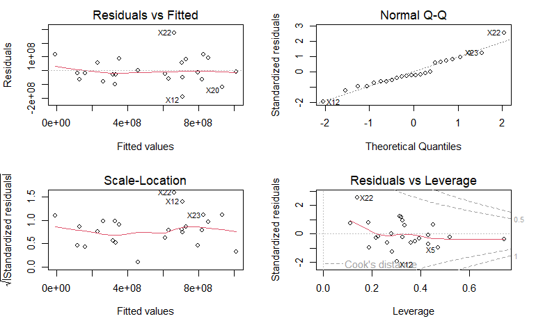

```r
par(mfrow = c(2,2))
plot(model_1_2$finalModel)
```

### 0.0.3 Adstock only

```r
ads_solver <- function(params, df){

  ads_rate_strategy1 = params[1]

  ads_rate_strategy2 = params[2]

  ads_rate_strategy3 = params[2]

  ads_rate_salesVisit1 = params[4]

  ads_rate_salesVisit2 = params[5]

  ads_rate_salesVisit3 = params[6]

  ads_rate_salesVisit4 = params[7]

  ads_rate_salesVisit5 = params[8]



  # transforming variables using a,b parameters that need to figured out
  df_optim_tranfm <- df %>%
  mutate(ads_strategy1 = strategy1,
         ads_strategy1 = if_else(row_number() == 1,
                               strategy1,
                               ( (strategy1 + lag(ads_strategy1)*ads_rate_strategy1) )
                               ) ,

         ads_strategy2 = strategy2,
         ads_strategy2 = if_else(row_number() == 1,
                               strategy2,
                               ( (strategy2 + lag(ads_strategy2)*ads_rate_strategy2) )
                               )  ,

         ads_strategy3 = strategy3,
         ads_strategy3 = if_else(row_number() == 1,
                               strategy3,
                               ( (strategy3 + lag(ads_strategy3)*ads_rate_strategy3) )
                               )  ,
         ads_salesVisit1 = salesVisit1,
         ads_salesVisit1 = if_else(row_number() == 1,
                               salesVisit1,
                               ( (salesVisit1 + lag(ads_salesVisit1)*ads_rate_salesVisit1) )
                               ) ,

         ads_salesVisit2 = salesVisit2,
         ads_salesVisit2 = if_else(row_number() == 1,
                               salesVisit2,
                               ( (salesVisit2 + lag(ads_salesVisit2)*ads_rate_salesVisit2) )
                               )  ,

         ads_salesVisit3 = salesVisit3,
         ads_salesVisit3 = if_else(row_number() == 1,
                               salesVisit3,
                               ( (salesVisit3 + lag(ads_salesVisit3)*ads_rate_salesVisit3) )
                               ) ,

             ads_salesVisit4 = salesVisit4,
         ads_salesVisit4 = if_else(row_number() == 1,
                               salesVisit4,
                               ( (salesVisit4 + lag(ads_salesVisit4)*ads_rate_salesVisit4) )
                               ) ,

         ads_salesVisit5 = salesVisit5,
         ads_salesVisit5 = if_else(row_number() == 1,
                               salesVisit5,
                               ( (salesVisit5 + lag(ads_salesVisit5)*ads_rate_salesVisit5) )
                               )
         )


  # setting seed for lm
  set.seed(2022)


  # creating model
  model_optim <- lm(sales ~ ads_strategy1+ads_strategy2+ads_strategy3+ads_salesVisit1+ads_salesVisit2+ads_salesVisit3+ads_salesVisit4+ads_salesVisit5,
                    data = df_optim_tranfm)

  # predicted values
  y_hat = predict(model_optim, df_optim_tranfm)

  # MAE that we need to minimize using optim
  MAE <- mean(abs(df_optim_tranfm$sales - y_hat))
  MAE


}
```

```r
optim(par = c(.1,.1,.1,.1,.1,.1,.1,.1), # initiating
      df = df1_monthly_aggr,
      fn = ads_solver,
      lower = c(.1,.1,.1,.1,.1,.1,.1,.1),
      upper = c(1,1,1,1,1,1,1,1),
      method = "L-BFGS-B")
```

```
$par
[1] 0.8629577 0.9011480 0.1000000 1.0000000 0.6324733 0.5727674 0.6053922 1.0000000

$value
[1] 50451269

$counts
function gradient
     111      111

$convergence
[1] 52

$message
[1] "ERROR: ABNORMAL_TERMINATION_IN_LNSRCH"
```

```r
  ads_rate_strategy1 = 0.8629577

  ads_rate_strategy2 = 0.9011480

  ads_rate_strategy3 = .1

  ads_rate_salesVisit1 = 1

  ads_rate_salesVisit2 = 0.6324733

  ads_rate_salesVisit3 = 0.5727674

  ads_rate_salesVisit4 = 0.6053922

  ads_rate_salesVisit5 = 1



  df1_ads_only <- df1_monthly_aggr %>%
  mutate(ads_strategy1 = strategy1,
         ads_strategy1 = if_else(row_number() == 1,
                               strategy1,
                               ( (strategy1 + lag(ads_strategy1)*ads_rate_strategy1) )
                               ) ,

         ads_strategy2 = strategy2,
         ads_strategy2 = if_else(row_number() == 1,
                               strategy2,
                               ( (strategy2 + lag(ads_strategy2)*ads_rate_strategy2) )
                               )  ,

         ads_strategy3 = strategy3,
         ads_strategy3 = if_else(row_number() == 1,
                               strategy3,
                               ( (strategy3 + lag(ads_strategy3)*ads_rate_strategy3) )
                               )  ,
         ads_salesVisit1 = salesVisit1,
         ads_salesVisit1 = if_else(row_number() == 1,
                               salesVisit1,
                               ( (salesVisit1 + lag(ads_salesVisit1)*ads_rate_salesVisit1) )
                               ) ,

         ads_salesVisit2 = salesVisit2,
         ads_salesVisit2 = if_else(row_number() == 1,
                               salesVisit2,
                               ( (salesVisit2 + lag(ads_salesVisit2)*ads_rate_salesVisit2) )
                               )  ,

         ads_salesVisit3 = salesVisit3,
         ads_salesVisit3 = if_else(row_number() == 1,
                               salesVisit3,
                               ( (salesVisit3 + lag(ads_salesVisit3)*ads_rate_salesVisit3) )
                               ) ,

             ads_salesVisit4 = salesVisit4,
         ads_salesVisit4 = if_else(row_number() == 1,
                               salesVisit4,
                               ( (salesVisit4 + lag(ads_salesVisit4)*ads_rate_salesVisit4) )
                               ) ,

         ads_salesVisit5 = salesVisit5,
         ads_salesVisit5 = if_else(row_number() == 1,
                               salesVisit5,
                               ( (salesVisit5 + lag(ads_salesVisit5)*ads_rate_salesVisit5) )
                               )
         )

  df1_ads_only
```

| month | sales | qty | strategy1 | strategy2 | strategy3 | salesVisit1 | salesVisit2 | salesVisit3 | salesVisit4 | salesVisit5 | compBrand_4 | ads_strategy1 | ads_strategy2 | ads_strategy3 | ads_salesVisit1 | ads_salesVisit2 | ads_salesVisit3 | ads_salesVisit4 | ads_salesVisit5 |
| --- | --- | --- | --- | --- | --- | --- | --- | --- | --- | --- | --- | --- | --- | --- | --- | --- | --- | --- | --- |
| 2013-10-01 | 63842150 | 598 | 0 | 0 | 0 | 375000 | 2775000 | 4575000 | 750000 | 150000 | 124 | 0 | 0 | 0 | 375000 | 2775000 | 4575000 | 750000.0 | 150000 |
| 2013-11-01 | 97681048 | 899 | 0 | 0 | 0 | 1050000 | 6075000 | 7050000 | 450000 | 225000 | 124 | 0 | 0 | 0 | 1425000 | 7830113 | 9670411 | 904044.2 | 375000 |
| 2013-12-01 | 107611101 | 1031 | 0 | 0 | 0 | 450000 | 8925000 | 9075000 | 675000 | 675000 | 124 | 0 | 0 | 0 | 1500000 | 12767275 | 13113010 | 947426.5 | 900000 |
| 2014-01-01 | 142387603 | 1357 | 1786168 | 8588657 | 0 | 2400000 | 30150000 | 32925000 | 2400000 | 750000 | 124 | 1786168 | 8588657 | 0 | 2850000 | 35794824 | 38122864 | 2808639.7 | 1425000 |
| 2014-02-01 | 181127597 | 1656 | 1438740 | 10468280 | 0 | 1950000 | 45375000 | 65700000 | 525000 | 825000 | 124 | 2980127 | 18207931 | 0 | 4350000 | 64444070 | 84558367 | 1977941.3 | 1575000 |
| 2014-03-01 | 228860049 | 2115 | 7110484 | 17098230 | 0 | 1575000 | 67200000 | 70575000 | 2625000 | 225000 | 124 | 8352056 | 26531700 | 0 | 3525000 | 95898476 | 108205818 | 2942830.9 | 1050000 |
| 2014-04-01 | 284263785 | 2634 | 10747114 | 22628073 | 0 | 900000 | 59025000 | 81150000 | 3600000 | 600000 | 124 | 16883161 | 38036109 | 0 | 2475000 | 101527206 | 121573059 | 5189154.5 | 825000 |
| 2014-05-01 | 287928955 | 2726 | 4939123 | 18932060 | 3032480 | 825000 | 52875000 | 66750000 | 2250000 | 375000 | 124 | 14213428 | 39323303 | 3032480 | 1725000 | 90206737 | 113230075 | 4429411.9 | 975000 |
| 2014-06-01 | 302973200 | 2910 | 9673247 | 20192525 | 0 | 975000 | 45375000 | 66075000 | 2025000 | 225000 | 124 | 13935501 | 37253113 | 303248 | 1800000 | 78817026 | 104307224 | 3387132.5 | 600000 |
| 2014-07-01 | 436496207 | 4099 | 5440573 | 19823339 | 0 | 2625000 | 74700000 | 78900000 | 2775000 | 375000 | 124 | 13788176 | 38019793 | 0 | 3600000 | 103398476 | 116745606 | 4000919.2 | 600000 |

[output cut: 14 more lines]

### 0.0.4 Model 2

```r
df_model2 <-  df1_ads_only %>%
  select(sales, contains("ads_"))

df_model2
```

| sales | ads_strategy1 | ads_strategy2 | ads_strategy3 | ads_salesVisit1 | ads_salesVisit2 | ads_salesVisit3 | ads_salesVisit4 | ads_salesVisit5 |
| --- | --- | --- | --- | --- | --- | --- | --- | --- |
| 63842150 | 0 | 0 | 0 | 375000 | 2775000 | 4575000 | 750000.0 | 150000 |
| 97681048 | 0 | 0 | 0 | 1425000 | 7830113 | 9670411 | 904044.2 | 375000 |
| 107611101 | 0 | 0 | 0 | 1500000 | 12767275 | 13113010 | 947426.5 | 900000 |
| 142387603 | 1786168 | 8588657 | 0 | 2850000 | 35794824 | 38122864 | 2808639.7 | 1425000 |
| 181127597 | 2980127 | 18207931 | 0 | 4350000 | 64444070 | 84558367 | 1977941.3 | 1575000 |
| 228860049 | 8352056 | 26531700 | 0 | 3525000 | 95898476 | 108205818 | 2942830.9 | 1050000 |
| 284263785 | 16883161 | 38036109 | 0 | 2475000 | 101527206 | 121573059 | 5189154.5 | 825000 |
| 287928955 | 14213428 | 39323303 | 3032480 | 1725000 | 90206737 | 113230075 | 4429411.9 | 975000 |
| 302973200 | 13935501 | 37253113 | 303248 | 1800000 | 78817026 | 104307224 | 3387132.5 | 600000 |
| 436496207 | 13788176 | 38019793 | 0 | 3600000 | 103398476 | 116745606 | 4000919.2 | 600000 |

[output cut: 14 more lines]

```r
# setting seed for lm
set.seed(2022)

model_2 <-  caret::train(sales ~ ., data = df_model2, method = "lm")
summary(model_2)
```

```
Call:
lm(formula = .outcome ~ ., data = dat)

Residuals:
       Min         1Q     Median         3Q        Max
-139623330  -31474444    1762926   28601483  183317782

Coefficients:
                    Estimate   Std. Error t value Pr(>|t|)
(Intercept)     99973687.695 64691230.257   1.545  0.14308
ads_strategy1         -6.656        9.628  -0.691  0.49992
ads_strategy2          1.546        3.391   0.456  0.65499
ads_strategy3         -6.864       11.148  -0.616  0.54730
ads_salesVisit1       15.529        5.800   2.678  0.01722 *
ads_salesVisit2        8.133        2.416   3.367  0.00424 **
ads_salesVisit3       -4.046        2.023  -1.999  0.06401 .
ads_salesVisit4      -16.773       27.092  -0.619  0.54513
ads_salesVisit5      -61.427       46.928  -1.309  0.21025
---
Signif. codes:  0 ‘***’ 0.001 ‘**’ 0.01 ‘*’ 0.05 ‘.’ 0.1 ‘ ’ 1

Residual standard error: 89860000 on 15 degrees of freedom
Multiple R-squared:  0.9449,    Adjusted R-squared:  0.9155
F-statistic: 32.16 on 8 and 15 DF,  p-value: 0.00000004403
```

#### 0.0.4.1 VIF

```r
mctest::imcdiag(model_2$finalModel, method = "VIF")
```

```
Call:
mctest::imcdiag(mod = model_2$finalModel, method = "VIF")


 VIF Multicollinearity Diagnostics

                    VIF detection
ads_strategy1    6.4005         0
ads_strategy2   15.1360         1
ads_strategy3    1.6739         0
ads_salesVisit1  2.8837         0
ads_salesVisit2 27.6762         1
ads_salesVisit3 13.2503         1
ads_salesVisit4  3.2962         0
ads_salesVisit5  1.5216         0

Multicollinearity may be due to ads_strategy2 ads_salesVisit2 ads_salesVisit3 regressors

1 --> COLLINEARITY is detected by the test
0 --> COLLINEARITY is not detected by the test

===================================
```

```r
# setting seed for lm
set.seed(2022)

model_2_2 <-  caret::train(sales ~ ads_strategy1+ads_strategy2+ads_strategy3+ads_salesVisit1+ads_salesVisit3+ads_salesVisit4+ads_salesVisit5,
                           data = df_model2, method = "lm")
summary(model_2_2)
```

```
Call:
lm(formula = .outcome ~ ., data = dat)

Residuals:
       Min         1Q     Median         3Q        Max
-164227557  -48984751   -6661164   46709208  255326176

Coefficients:
                     Estimate    Std. Error t value   Pr(>|t|)
(Intercept)     102551157.114  82990945.867   1.236   0.234410
ads_strategy1         -24.020        10.431  -2.303   0.035062 *
ads_strategy2          11.954         1.788   6.684 0.00000525 ***
ads_strategy3         -20.354        13.346  -1.525   0.146757
ads_salesVisit1        26.427         6.174   4.280   0.000574 ***
ads_salesVisit3         1.227         1.644   0.746   0.466427
ads_salesVisit4        -6.165        34.522  -0.179   0.860511
ads_salesVisit5       -98.283        58.546  -1.679   0.112625
---
Signif. codes:  0 ‘***’ 0.001 ‘**’ 0.01 ‘*’ 0.05 ‘.’ 0.1 ‘ ’ 1

Residual standard error: 115300000 on 16 degrees of freedom
Multiple R-squared:  0.9033,    Adjusted R-squared:  0.8609
F-statistic: 21.34 on 7 and 16 DF,  p-value: 0.000000544
```

```r
mctest::imcdiag(model_2_2$finalModel, method = "VIF")
```

```
Call:
mctest::imcdiag(mod = model_2_2$finalModel, method = "VIF")


 VIF Multicollinearity Diagnostics

                   VIF detection
ads_strategy1   4.5643         0
ads_strategy2   2.5579         0
ads_strategy3   1.4577         0
ads_salesVisit1 1.9855         0
ads_salesVisit3 5.3142         0
ads_salesVisit4 3.2517         0
ads_salesVisit5 1.4388         0

NOTE:  VIF Method Failed to detect multicollinearity


0 --> COLLINEARITY is not detected by the test

===================================
```

#### 0.0.4.2 heteroscadasticity

```r
lmtest::bptest(model_2_2$finalModel)
```

```
    studentized Breusch-Pagan test

data:  model_2_2$finalModel
BP = 8.2644, df = 7, p-value = 0.3099
```

No heteroscadasticity in the model as the p-value is greater than 0.05

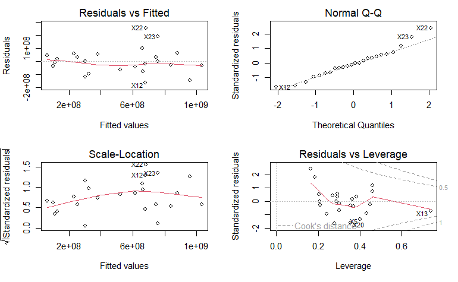

```r
par(mfrow = c(2,2))
plot(model_2_2$finalModel)
```

### 0.0.5 Model 3 RFE

#### 0.0.5.1 Normalizing Adstock

```r
df_train <- df_model2[,]
dim(df_train)
```

```
[1] 24  9
```

Using Range to convert negative values to positive

```r
preprocess_step <- caret::preProcess(df_train, method = c("center","scale"))

df_train <- predict(preprocess_step, newdata = df_train)


# To limit range between 0 to 1 & keep it positive
preprocess_step <- caret::preProcess(df_train, method = c("range"))

df_train <- predict(preprocess_step, newdata = df_train)

# to make it normally distributed
preprocess_step <- caret::preProcess(df_train, method = c("BoxCox"))

df_train <- predict(preprocess_step, newdata = df_train)


anyNA(df_train)
```

```
[1] FALSE
```

```r
df_train
```

| sales | ads_strategy1 | ads_strategy2 | ads_strategy3 | ads_salesVisit1 | ads_salesVisit2 | ads_salesVisit3 | ads_salesVisit4 | ads_salesVisit5 |
| --- | --- | --- | --- | --- | --- | --- | --- | --- |
| 0.00000000 | 0.0000000 | 0.0000000 | 0.00000000 | 0.00000000 | 0.00000000 | 0.00000000 | 0.00000000 | 0.00000000 |
| 0.03618961 | 0.0000000 | 0.0000000 | 0.00000000 | 0.05645161 | 0.03470173 | 0.04355124 | 0.03470124 | 0.12500000 |
| 0.04680948 | 0.0000000 | 0.0000000 | 0.00000000 | 0.06048387 | 0.06859377 | 0.07297566 | 0.04447389 | 0.41666667 |
| 0.08400182 | 0.1057958 | 0.1207348 | 0.00000000 | 0.13306452 | 0.22667051 | 0.28673864 | 0.46374591 | 0.70833333 |
| 0.12543300 | 0.1765148 | 0.2559575 | 0.00000000 | 0.21370968 | 0.42333840 | 0.68362986 | 0.27661603 | 0.79166667 |
| 0.17648131 | 0.4946974 | 0.3729686 | 0.00000000 | 0.16935484 | 0.63926281 | 0.88574818 | 0.49397490 | 0.50000000 |
| 0.23573382 | 1.0000000 | 0.5346916 | 0.00000000 | 0.11290323 | 0.67790223 | 1.00000000 | 1.00000000 | 0.37500000 |
| 0.23965360 | 0.8418701 | 0.5527863 | 0.31878132 | 0.07258065 | 0.60019084 | 0.92869126 | 0.82885421 | 0.45833333 |
| 0.25574293 | 0.8254083 | 0.5236846 | 0.03187813 | 0.07661290 | 0.52200413 | 0.85242631 | 0.59406187 | 0.25000000 |
| 0.39854148 | 0.8166821 | 0.5344622 | 0.00000000 | 0.17338710 | 0.69074791 | 0.95873903 | 0.73232846 | 0.25000000 |

[output cut: 14 more lines]

#### 0.0.5.2 RFE

```r
set.seed(100)
options(warn=-1)

subsets <- c(1:5, 10, 15)

ctrl <- rfeControl(functions = lmFuncs, #rfFuncs,
                   method = "repeatedcv",
                   repeats = 5,
                   verbose = FALSE)

lmProfile <- rfe(x=df_train %>% select(-sales), y=df_train$sales,
                 sizes = subsets,
                 rfeControl = ctrl)

lmProfile
```

```
Recursive feature selection

Outer resampling method: Cross-Validated (10 fold, repeated 5 times)

Resampling performance over subset size:
```

|  | Variables | RMSE | Rsquared | MAE | RMSESD | RsquaredSD | MAESD | Selected |
| --- | --- | --- | --- | --- | --- | --- | --- | --- |
| 1 | 1 | 0.17608 | 0.9095 | 0.16292 | 0.07113 | 0.1975 | 0.07104 |  |
| 2 | 2 | 0.10124 | 0.9248 | 0.08789 | 0.05818 | 0.1922 | 0.05301 |  |
| 3 | 3 | 0.08861 | 0.9313 | 0.07786 | 0.04796 | 0.1934 | 0.04384 | * |
| 4 | 4 | 0.10134 | 0.9174 | 0.08953 | 0.05372 | 0.2020 | 0.04803 |  |
| 5 | 5 | 0.10586 | 0.9205 | 0.09141 | 0.05531 | 0.1977 | 0.05066 |  |
| 6 | 8 | 0.10531 | 0.9335 | 0.09238 | 0.06175 | 0.1976 | 0.05741 |  |

```
The top 3 variables (out of 3):
   ads_salesVisit2, ads_salesVisit3, ads_salesVisit1
```

#### 0.0.5.3 Model

```r
# setting seed for lm
set.seed(2022)

model_3 <-  caret::train(sales ~ ads_salesVisit1 + ads_salesVisit2 + ads_salesVisit3,
                         data = df_train, method = "lm")
summary(model_3)
```

```
Call:
lm(formula = .outcome ~ ., data = dat)

Residuals:
      Min        1Q    Median        3Q       Max
-0.134566 -0.062710 -0.004067  0.043619  0.220182

Coefficients:
                  Estimate Std. Error t value       Pr(>|t|)
(Intercept)     -0.0005722  0.0489579  -0.012        0.99079
ads_salesVisit1  0.2451765  0.0765684   3.202        0.00448 **
ads_salesVisit2  1.4880314  0.1271543  11.703 0.000000000212 ***
ads_salesVisit3 -0.7690054  0.1103870  -6.966 0.000000921546 ***
---
Signif. codes:  0 ‘***’ 0.001 ‘**’ 0.01 ‘*’ 0.05 ‘.’ 0.1 ‘ ’ 1

Residual standard error: 0.08962 on 20 degrees of freedom
Multiple R-squared:  0.9361,    Adjusted R-squared:  0.9265
F-statistic: 97.69 on 3 and 20 DF,  p-value: 0.000000000004067
```

#### 0.0.5.4 VIF

```r
mctest::imcdiag(model_3$finalModel, method = "VIF")
```

```
Call:
mctest::imcdiag(mod = model_3$finalModel, method = "VIF")


 VIF Multicollinearity Diagnostics

                   VIF detection
ads_salesVisit1 1.4606         0
ads_salesVisit2 3.6330         0
ads_salesVisit3 2.8966         0

NOTE:  VIF Method Failed to detect multicollinearity


0 --> COLLINEARITY is not detected by the test

===================================
```

#### 0.0.5.5 heteroscadasticity

```r
lmtest::bptest(model_3$finalModel)
```

```
    studentized Breusch-Pagan test

data:  model_3$finalModel
BP = 1.1659, df = 3, p-value = 0.7612
```

No heteroscadasticity in the model as the p-value is greater than 0.05

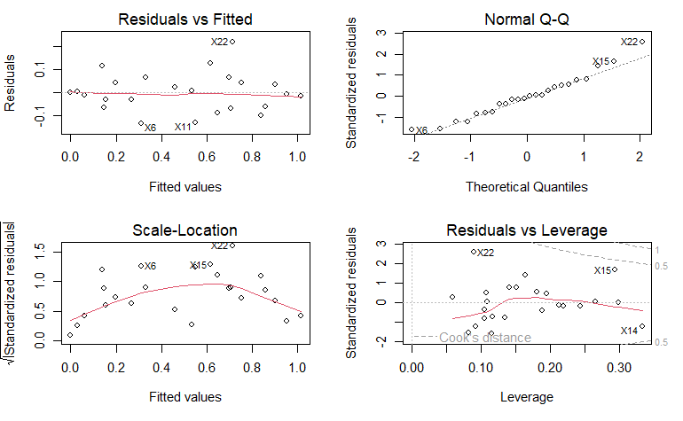

```r
par(mfrow = c(2,2))
plot(model_3$finalModel)
```

### 0.0.6 Model 4 All vars

#### 0.0.6.1 Normalizing data etc.

```r
df_train <- df_model2[,]
dim(df_train)
```

```
[1] 24  9
```

Using Range to convert negative values to positive

```r
preprocess_step <- caret::preProcess(df_train, method = c("center","scale"))

df_train <- predict(preprocess_step, newdata = df_train)


# To limit range between 0 to 1 & keep it positive
preprocess_step <- caret::preProcess(df_train, method = c("range"))

df_train <- predict(preprocess_step, newdata = df_train)

# to make it normally distributed
preprocess_step <- caret::preProcess(df_train, method = c("BoxCox"))

df_train <- predict(preprocess_step, newdata = df_train)


anyNA(df_train)
```

```
[1] FALSE
```

```r
df_train
```

| sales | ads_strategy1 | ads_strategy2 | ads_strategy3 | ads_salesVisit1 | ads_salesVisit2 | ads_salesVisit3 | ads_salesVisit4 | ads_salesVisit5 |
| --- | --- | --- | --- | --- | --- | --- | --- | --- |
| 0.00000000 | 0.0000000 | 0.0000000 | 0.00000000 | 0.00000000 | 0.00000000 | 0.00000000 | 0.00000000 | 0.00000000 |
| 0.03618961 | 0.0000000 | 0.0000000 | 0.00000000 | 0.05645161 | 0.03470173 | 0.04355124 | 0.03470124 | 0.12500000 |
| 0.04680948 | 0.0000000 | 0.0000000 | 0.00000000 | 0.06048387 | 0.06859377 | 0.07297566 | 0.04447389 | 0.41666667 |
| 0.08400182 | 0.1057958 | 0.1207348 | 0.00000000 | 0.13306452 | 0.22667051 | 0.28673864 | 0.46374591 | 0.70833333 |
| 0.12543300 | 0.1765148 | 0.2559575 | 0.00000000 | 0.21370968 | 0.42333840 | 0.68362986 | 0.27661603 | 0.79166667 |
| 0.17648131 | 0.4946974 | 0.3729686 | 0.00000000 | 0.16935484 | 0.63926281 | 0.88574818 | 0.49397490 | 0.50000000 |
| 0.23573382 | 1.0000000 | 0.5346916 | 0.00000000 | 0.11290323 | 0.67790223 | 1.00000000 | 1.00000000 | 0.37500000 |
| 0.23965360 | 0.8418701 | 0.5527863 | 0.31878132 | 0.07258065 | 0.60019084 | 0.92869126 | 0.82885421 | 0.45833333 |
| 0.25574293 | 0.8254083 | 0.5236846 | 0.03187813 | 0.07661290 | 0.52200413 | 0.85242631 | 0.59406187 | 0.25000000 |
| 0.39854148 | 0.8166821 | 0.5344622 | 0.00000000 | 0.17338710 | 0.69074791 | 0.95873903 | 0.73232846 | 0.25000000 |

[output cut: 14 more lines]

#### 0.0.6.2 Model

```r
# setting seed for lm
set.seed(2022)

model_4 <-  caret::train(sales ~ .,
                    data = df_train, method = "lm")
summary(model_4)
```

```
Call:
lm(formula = .outcome ~ ., data = dat)

Residuals:
      Min        1Q    Median        3Q       Max
-0.149323 -0.033661  0.001885  0.030588  0.196052

Coefficients:
                Estimate Std. Error t value Pr(>|t|)
(Intercept)      0.02590    0.05853   0.443  0.66436
ads_strategy1   -0.12018    0.17385  -0.691  0.49992
ads_strategy2    0.11762    0.25799   0.456  0.65499
ads_strategy3   -0.06983    0.11341  -0.616  0.54730
ads_salesVisit1  0.30890    0.11537   2.678  0.01722 *
ads_salesVisit2  1.26710    0.37634   3.367  0.00424 **
ads_salesVisit3 -0.50621    0.25317  -1.999  0.06401 .
ads_salesVisit4 -0.07963    0.12862  -0.619  0.54513
ads_salesVisit5 -0.11825    0.09034  -1.309  0.21025
---
Signif. codes:  0 ‘***’ 0.001 ‘**’ 0.01 ‘*’ 0.05 ‘.’ 0.1 ‘ ’ 1

Residual standard error: 0.0961 on 15 degrees of freedom
Multiple R-squared:  0.9449,    Adjusted R-squared:  0.9155
F-statistic: 32.16 on 8 and 15 DF,  p-value: 0.00000004403
```

#### 0.0.6.3 vif

```r
library(mctest)
```

```r
mctest::imcdiag(model_4$finalModel, method = "VIF")
```

```
Call:
mctest::imcdiag(mod = model_4$finalModel, method = "VIF")


 VIF Multicollinearity Diagnostics

                    VIF detection
ads_strategy1    6.4005         0
ads_strategy2   15.1360         1
ads_strategy3    1.6739         0
ads_salesVisit1  2.8837         0
ads_salesVisit2 27.6762         1
ads_salesVisit3 13.2503         1
ads_salesVisit4  3.2962         0
ads_salesVisit5  1.5216         0

Multicollinearity may be due to ads_strategy2 ads_salesVisit2 ads_salesVisit3 regressors

1 --> COLLINEARITY is detected by the test
0 --> COLLINEARITY is not detected by the test

===================================
```

```r
# setting seed for lm
set.seed(2022)

model_4_2 <-  caret::train(sales ~ ads_strategy1+ads_strategy2+ads_strategy3+ads_salesVisit1+ads_salesVisit3+ads_salesVisit4+ads_salesVisit5,
                    data = df_train, method = "lm")
summary(model_4_2)
```

```
Call:
lm(formula = .outcome ~ ., data = dat)

Residuals:
      Min        1Q    Median        3Q       Max
-0.175636 -0.052388 -0.007124  0.049954  0.273063

Coefficients:
                Estimate Std. Error t value   Pr(>|t|)
(Intercept)      0.03729    0.07496   0.497   0.625674
ads_strategy1   -0.43370    0.18835  -2.303   0.035062 *
ads_strategy2    0.90945    0.13607   6.684 0.00000525 ***
ads_strategy3   -0.20707    0.13578  -1.525   0.146757
ads_salesVisit1  0.52568    0.12282   4.280   0.000574 ***
ads_salesVisit3  0.15347    0.20570   0.746   0.466427
ads_salesVisit4 -0.02927    0.16389  -0.179   0.860511
ads_salesVisit5 -0.18920    0.11270  -1.679   0.112625
---
Signif. codes:  0 ‘***’ 0.001 ‘**’ 0.01 ‘*’ 0.05 ‘.’ 0.1 ‘ ’ 1

Residual standard error: 0.1233 on 16 degrees of freedom
Multiple R-squared:  0.9033,    Adjusted R-squared:  0.8609
F-statistic: 21.34 on 7 and 16 DF,  p-value: 0.000000544
```

```r
mctest::imcdiag(model_4_2$finalModel, method= "VIF")
```

```
Call:
mctest::imcdiag(mod = model_4_2$finalModel, method = "VIF")


 VIF Multicollinearity Diagnostics

                   VIF detection
ads_strategy1   4.5643         0
ads_strategy2   2.5579         0
ads_strategy3   1.4577         0
ads_salesVisit1 1.9855         0
ads_salesVisit3 5.3142         0
ads_salesVisit4 3.2517         0
ads_salesVisit5 1.4388         0

NOTE:  VIF Method Failed to detect multicollinearity


0 --> COLLINEARITY is not detected by the test

===================================
```

#### 0.0.6.4 heteroscadasticity

```r
lmtest::bptest(model_4_2$finalModel)
```

```
    studentized Breusch-Pagan test

data:  model_4_2$finalModel
BP = 8.2644, df = 7, p-value = 0.3099
```

No heteroscadasticity in the model as the p-value is greater than 0.05

### 0.0.7 Model 5 log

```r
df_train <- df_model2[,]
dim(df_train)
```

```
[1] 24  9
```

```r
df_train <- log1p(df_train)
df_train
```

| sales | ads_strategy1 | ads_strategy2 | ads_strategy3 | ads_salesVisit1 | ads_salesVisit2 | ads_salesVisit3 | ads_salesVisit4 | ads_salesVisit5 |
| --- | --- | --- | --- | --- | --- | --- | --- | --- |
| 17.97192 | 0.00000 | 0.00000 | 0.00000 | 12.83468 | 14.83616 | 15.33612 | 13.52783 | 11.91840 |
| 18.39722 | 0.00000 | 0.00000 | 0.00000 | 14.16968 | 15.87349 | 16.08458 | 13.71463 | 12.83468 |
| 18.49403 | 0.00000 | 0.00000 | 0.00000 | 14.22098 | 16.36240 | 16.38912 | 13.76151 | 13.71015 |
| 18.77406 | 14.39558 | 15.96595 | 0.00000 | 14.86283 | 17.39331 | 17.45632 | 14.84821 | 14.16968 |
| 19.01471 | 14.90748 | 16.71737 | 0.00000 | 15.28569 | 17.98131 | 18.25295 | 14.49757 | 14.26977 |
| 19.24862 | 15.93802 | 17.09385 | 0.00000 | 15.07539 | 18.37880 | 18.49955 | 14.89488 | 13.86430 |
| 19.46541 | 16.64183 | 17.45405 | 0.00000 | 14.72175 | 18.43584 | 18.61603 | 15.46208 | 13.62314 |
| 19.47822 | 16.46970 | 17.48733 | 14.92489 | 14.36074 | 18.31761 | 18.54493 | 15.30378 | 13.79019 |
| 19.52915 | 16.44995 | 17.43325 | 12.62231 | 14.40330 | 18.18264 | 18.46285 | 15.03549 | 13.30469 |
| 19.89429 | 16.43932 | 17.45362 | 0.00000 | 15.09644 | 18.45410 | 18.57551 | 15.20203 | 13.30469 |

[output cut: 14 more lines]

Using Range to convert negative values to positive

```r
preprocess_step <- caret::preProcess(df_train, method = c("center","scale"))

df_train <- predict(preprocess_step, newdata = df_train)


# To limit range between 0 to 1 & keep it positive
preprocess_step <- caret::preProcess(df_train, method = c("range"))

df_train <- predict(preprocess_step, newdata = df_train)

# to make it normally distributed
preprocess_step <- caret::preProcess(df_train, method = c("BoxCox"))

df_train <- predict(preprocess_step, newdata = df_train)


anyNA(df_train)
```

```
[1] FALSE
```

```r
df_train
```

| sales | ads_strategy1 | ads_strategy2 | ads_strategy3 | ads_salesVisit1 | ads_salesVisit2 | ads_salesVisit3 | ads_salesVisit4 | ads_salesVisit5 |
| --- | --- | --- | --- | --- | --- | --- | --- | --- |
| 0.0000000 | 0.0000000 | 0.0000000 | 0.0000000 | 0.0000000 | 0.0000000 | 0.0000000 | 0.00000000 | 0.0000000 |
| 0.1546395 | 0.0000000 | 0.0000000 | 0.0000000 | 0.3402183 | 0.2606618 | 0.2281966 | 0.09657728 | 0.3572347 |
| 0.1898425 | 0.0000000 | 0.0000000 | 0.0000000 | 0.3532901 | 0.3835159 | 0.3210449 | 0.12080944 | 0.6985550 |
| 0.2916629 | 0.8650242 | 0.8830672 | 0.0000000 | 0.5168635 | 0.6425675 | 0.6464227 | 0.68263162 | 0.8777137 |
| 0.3791643 | 0.8957837 | 0.9246275 | 0.0000000 | 0.6246265 | 0.7903202 | 0.8893038 | 0.50135036 | 0.9167334 |
| 0.4642150 | 0.9577084 | 0.9454505 | 0.0000000 | 0.5710338 | 0.8902031 | 0.9644867 | 0.70676070 | 0.7586540 |
| 0.5430419 | 1.0000000 | 0.9653727 | 0.0000000 | 0.4809103 | 0.9045354 | 1.0000000 | 1.00000000 | 0.6646317 |
| 0.5477001 | 0.9896568 | 0.9672135 | 0.9288499 | 0.3889078 | 0.8748281 | 0.9783245 | 0.91815754 | 0.7297614 |
| 0.5662188 | 0.9884702 | 0.9642223 | 0.7855488 | 0.3997539 | 0.8409113 | 0.9532991 | 0.77945632 | 0.5404757 |
| 0.6989843 | 0.9878315 | 0.9653490 | 0.0000000 | 0.5763991 | 0.9091247 | 0.9876466 | 0.86555701 | 0.5404757 |

[output cut: 14 more lines]

#### 0.0.7.1 Model

```r
# setting seed for lm
set.seed(2022)

model_5 <-  caret::train(sales ~ .,
                    data = df_train, method = "lm")
summary(model_5)
```

```
Call:
lm(formula = .outcome ~ ., data = dat)

Residuals:
     Min       1Q   Median       3Q      Max
-0.13367 -0.04514 -0.01174  0.05601  0.11876

Coefficients:
                Estimate Std. Error t value Pr(>|t|)
(Intercept)     -0.10429    0.07822  -1.333  0.20235
ads_strategy1    0.21904    1.34255   0.163  0.87257
ads_strategy2   -0.14381    1.24479  -0.116  0.90956
ads_strategy3    0.02443    0.05708   0.428  0.67470
ads_salesVisit1  0.39270    0.16390   2.396  0.03006 *
ads_salesVisit2  1.83448    0.52445   3.498  0.00324 **
ads_salesVisit3 -1.02284    0.55211  -1.853  0.08372 .
ads_salesVisit4 -0.11683    0.17428  -0.670  0.51280
ads_salesVisit5 -0.21071    0.10152  -2.076  0.05554 .
---
Signif. codes:  0 ‘***’ 0.001 ‘**’ 0.01 ‘*’ 0.05 ‘.’ 0.1 ‘ ’ 1

Residual standard error: 0.09245 on 15 degrees of freedom
Multiple R-squared:  0.9365,    Adjusted R-squared:  0.9026
F-statistic: 27.63 on 8 and 15 DF,  p-value: 0.0000001253
```

#### 0.0.7.2 vif

```r
mctest::imcdiag(model_5$finalModel, method = "VIF")
```

```
Call:
mctest::imcdiag(mod = model_5$finalModel, method = "VIF")


 VIF Multicollinearity Diagnostics

                     VIF detection
ads_strategy1   506.7921         1
ads_strategy2   445.0910         1
ads_strategy3     1.5392         0
ads_salesVisit1   4.5162         0
ads_salesVisit2  46.4616         1
ads_salesVisit3  56.1207         1
ads_salesVisit4   6.3123         0
ads_salesVisit5   1.7658         0

Multicollinearity may be due to ads_strategy1 ads_strategy2 ads_salesVisit2 ads_salesVisit3 regressors

1 --> COLLINEARITY is detected by the test
0 --> COLLINEARITY is not detected by the test

===================================
```

```r
# setting seed for lm
set.seed(2022)

model_5_2 <-  caret::train(sales ~ ads_strategy2+ads_strategy3+ads_salesVisit1+ads_salesVisit4+ads_salesVisit5,
                    data = df_train, method = "lm")
summary(model_5_2)
```

```
Call:
lm(formula = .outcome ~ ., data = dat)

Residuals:
     Min       1Q   Median       3Q      Max
-0.23829 -0.04378  0.01892  0.07085  0.16976

Coefficients:
                  Estimate Std. Error t value  Pr(>|t|)
(Intercept)      0.0365332  0.0867753   0.421    0.6787
ads_strategy2    0.4874604  0.1782543   2.735    0.0136 *
ads_strategy3   -0.0004775  0.0726009  -0.007    0.9948
ads_salesVisit1  0.8076737  0.1407984   5.736 0.0000194 ***
ads_salesVisit4 -0.1766355  0.2018153  -0.875    0.3930
ads_salesVisit5 -0.3116922  0.1139874  -2.734    0.0136 *
---
Signif. codes:  0 ‘***’ 0.001 ‘**’ 0.01 ‘*’ 0.05 ‘.’ 0.1 ‘ ’ 1

Residual standard error: 0.1213 on 18 degrees of freedom
Multiple R-squared:  0.8688,    Adjusted R-squared:  0.8323
F-statistic: 23.83 on 5 and 18 DF,  p-value: 0.000000236
```

```r
mctest::imcdiag(model_5_2$finalModel, method = "VIF")
```

```
Call:
mctest::imcdiag(mod = model_5_2$finalModel, method = "VIF")


 VIF Multicollinearity Diagnostics

                   VIF detection
ads_strategy2   5.3028         0
ads_strategy3   1.4465         0
ads_salesVisit1 1.9363         0
ads_salesVisit4 4.9181         0
ads_salesVisit5 1.2935         0

NOTE:  VIF Method Failed to detect multicollinearity


0 --> COLLINEARITY is not detected by the test

===================================
```

#### 0.0.7.3 heteroscadasticity

```r
lmtest::bptest(model_5_2$finalModel)
```

```
    studentized Breusch-Pagan test

data:  model_5_2$finalModel
BP = 11.013, df = 5, p-value = 0.05112
```

No heteroscadasticity in the model as the p-value is greater than 0.05

### 0.0.8 Model 6 log RFE

```r
df_train <- df_model2[,]
dim(df_train)
```

```
[1] 24  9
```

```r
df_train <- log1p(df_train)
df_train
```

| sales | ads_strategy1 | ads_strategy2 | ads_strategy3 | ads_salesVisit1 | ads_salesVisit2 | ads_salesVisit3 | ads_salesVisit4 | ads_salesVisit5 |
| --- | --- | --- | --- | --- | --- | --- | --- | --- |
| 17.97192 | 0.00000 | 0.00000 | 0.00000 | 12.83468 | 14.83616 | 15.33612 | 13.52783 | 11.91840 |
| 18.39722 | 0.00000 | 0.00000 | 0.00000 | 14.16968 | 15.87349 | 16.08458 | 13.71463 | 12.83468 |
| 18.49403 | 0.00000 | 0.00000 | 0.00000 | 14.22098 | 16.36240 | 16.38912 | 13.76151 | 13.71015 |
| 18.77406 | 14.39558 | 15.96595 | 0.00000 | 14.86283 | 17.39331 | 17.45632 | 14.84821 | 14.16968 |
| 19.01471 | 14.90748 | 16.71737 | 0.00000 | 15.28569 | 17.98131 | 18.25295 | 14.49757 | 14.26977 |
| 19.24862 | 15.93802 | 17.09385 | 0.00000 | 15.07539 | 18.37880 | 18.49955 | 14.89488 | 13.86430 |
| 19.46541 | 16.64183 | 17.45405 | 0.00000 | 14.72175 | 18.43584 | 18.61603 | 15.46208 | 13.62314 |
| 19.47822 | 16.46970 | 17.48733 | 14.92489 | 14.36074 | 18.31761 | 18.54493 | 15.30378 | 13.79019 |
| 19.52915 | 16.44995 | 17.43325 | 12.62231 | 14.40330 | 18.18264 | 18.46285 | 15.03549 | 13.30469 |
| 19.89429 | 16.43932 | 17.45362 | 0.00000 | 15.09644 | 18.45410 | 18.57551 | 15.20203 | 13.30469 |

[output cut: 14 more lines]

#### 0.0.8.1 Normalizing Adstock

Using Range to convert negative values to positive

```r
preprocess_step <- caret::preProcess(df_train, method = c("center","scale"))

df_train <- predict(preprocess_step, newdata = df_train)


# To limit range between 0 to 1 & keep it positive
preprocess_step <- caret::preProcess(df_train, method = c("range"))

df_train <- predict(preprocess_step, newdata = df_train)

# to make it normally distributed
preprocess_step <- caret::preProcess(df_train, method = c("BoxCox"))

df_train <- predict(preprocess_step, newdata = df_train)


anyNA(df_train)
```

```
[1] FALSE
```

```r
df_train
```

| sales | ads_strategy1 | ads_strategy2 | ads_strategy3 | ads_salesVisit1 | ads_salesVisit2 | ads_salesVisit3 | ads_salesVisit4 | ads_salesVisit5 |
| --- | --- | --- | --- | --- | --- | --- | --- | --- |
| 0.0000000 | 0.0000000 | 0.0000000 | 0.0000000 | 0.0000000 | 0.0000000 | 0.0000000 | 0.00000000 | 0.0000000 |
| 0.1546395 | 0.0000000 | 0.0000000 | 0.0000000 | 0.3402183 | 0.2606618 | 0.2281966 | 0.09657728 | 0.3572347 |
| 0.1898425 | 0.0000000 | 0.0000000 | 0.0000000 | 0.3532901 | 0.3835159 | 0.3210449 | 0.12080944 | 0.6985550 |
| 0.2916629 | 0.8650242 | 0.8830672 | 0.0000000 | 0.5168635 | 0.6425675 | 0.6464227 | 0.68263162 | 0.8777137 |
| 0.3791643 | 0.8957837 | 0.9246275 | 0.0000000 | 0.6246265 | 0.7903202 | 0.8893038 | 0.50135036 | 0.9167334 |
| 0.4642150 | 0.9577084 | 0.9454505 | 0.0000000 | 0.5710338 | 0.8902031 | 0.9644867 | 0.70676070 | 0.7586540 |
| 0.5430419 | 1.0000000 | 0.9653727 | 0.0000000 | 0.4809103 | 0.9045354 | 1.0000000 | 1.00000000 | 0.6646317 |
| 0.5477001 | 0.9896568 | 0.9672135 | 0.9288499 | 0.3889078 | 0.8748281 | 0.9783245 | 0.91815754 | 0.7297614 |
| 0.5662188 | 0.9884702 | 0.9642223 | 0.7855488 | 0.3997539 | 0.8409113 | 0.9532991 | 0.77945632 | 0.5404757 |
| 0.6989843 | 0.9878315 | 0.9653490 | 0.0000000 | 0.5763991 | 0.9091247 | 0.9876466 | 0.86555701 | 0.5404757 |

[output cut: 14 more lines]

#### 0.0.8.2 RFE

```r
set.seed(100)
options(warn=-1)

subsets <- c(1:5, 10, 15)

ctrl <- rfeControl(functions = lmFuncs, #rfFuncs,
                   method = "repeatedcv",
                   repeats = 5,
                   verbose = FALSE)

lmProfile <- rfe(x=df_train %>% select(-sales), y=df_train$sales,
                 sizes = subsets,
                 rfeControl = ctrl)

lmProfile
```

```
Recursive feature selection

Outer resampling method: Cross-Validated (10 fold, repeated 5 times)

Resampling performance over subset size:
```

|  | Variables | RMSE | Rsquared | MAE | RMSESD | RsquaredSD | MAESD | Selected |
| --- | --- | --- | --- | --- | --- | --- | --- | --- |
| 1 | 1 | 0.1556 | 0.9319 | 0.1419 | 0.06317 | 0.1753 | 0.06274 |  |
| 2 | 2 | 0.1277 | 0.9130 | 0.1073 | 0.08488 | 0.2141 | 0.06985 |  |
| 3 | 3 | 0.1254 | 0.9114 | 0.1077 | 0.08225 | 0.2184 | 0.06982 |  |
| 4 | 4 | 0.1294 | 0.9220 | 0.1111 | 0.08633 | 0.1940 | 0.07149 |  |
| 5 | 5 | 0.1244 | 0.9417 | 0.1058 | 0.07981 | 0.1755 | 0.06519 | * |
| 6 | 8 | 0.1333 | 0.9522 | 0.1181 | 0.06028 | 0.1382 | 0.05393 |  |

```
The top 5 variables (out of 5):
   ads_salesVisit2, ads_salesVisit3, ads_strategy1, ads_strategy2, ads_salesVisit1
```

#### 0.0.8.3 Model

```r
# setting seed for lm
set.seed(2022)

model_6 <-  caret::train(sales ~ ads_strategy1+ads_strategy2+ads_salesVisit1+ads_salesVisit2+ads_salesVisit3,
                    data = df_train, method = "lm")
summary(model_6)
```

```
Call:
lm(formula = .outcome ~ ., data = dat)

Residuals:
      Min        1Q    Median        3Q       Max
-0.213176 -0.028192 -0.003736  0.053984  0.165656

Coefficients:
                Estimate Std. Error t value Pr(>|t|)
(Intercept)     -0.16566    0.07995  -2.072 0.052897 .
ads_strategy1    0.09935    1.39543   0.071 0.944024
ads_strategy2   -0.04681    1.31191  -0.036 0.971928
ads_salesVisit1  0.28327    0.16010   1.769 0.093787 .
ads_salesVisit2  2.18500    0.52488   4.163 0.000585 ***
ads_salesVisit3 -1.43023    0.53415  -2.678 0.015366 *
---
Signif. codes:  0 ‘***’ 0.001 ‘**’ 0.01 ‘*’ 0.05 ‘.’ 0.1 ‘ ’ 1

Residual standard error: 0.1 on 18 degrees of freedom
Multiple R-squared:  0.9108,    Adjusted R-squared:  0.886
F-statistic: 36.75 on 5 and 18 DF,  p-value: 0.000000007796
```

#### 0.0.8.4 vif

```r
mctest::imcdiag(model_6$finalModel, method = "VIF")
```

```
Call:
mctest::imcdiag(mod = model_6$finalModel, method = "VIF")


 VIF Multicollinearity Diagnostics

                     VIF detection
ads_strategy1   467.9059         1
ads_strategy2   422.5120         1
ads_salesVisit1   3.6828         0
ads_salesVisit2  39.7718         1
ads_salesVisit3  44.8922         1

Multicollinearity may be due to ads_strategy1 ads_strategy2 ads_salesVisit2 ads_salesVisit3 regressors

1 --> COLLINEARITY is detected by the test
0 --> COLLINEARITY is not detected by the test

===================================
```

```r
# setting seed for lm
set.seed(2022)

model_6_2 <-  caret::train(sales ~ ads_strategy2+ads_salesVisit1+ads_salesVisit2+ads_salesVisit3,
                    data = df_train, method = "lm")
summary(model_6_2)
```

```
Call:
lm(formula = .outcome ~ ., data = dat)

Residuals:
      Min        1Q    Median        3Q       Max
-0.212492 -0.026502 -0.003257  0.052117  0.166109

Coefficients:
                Estimate Std. Error t value Pr(>|t|)
(Intercept)     -0.16611    0.07758  -2.141 0.045435 *
ads_strategy2    0.04529    0.21270   0.213 0.833645
ads_salesVisit1  0.28012    0.14978   1.870 0.076944 .
ads_salesVisit2  2.16874    0.46005   4.714 0.000151 ***
ads_salesVisit3 -1.40477    0.38627  -3.637 0.001755 **
---
Signif. codes:  0 ‘***’ 0.001 ‘**’ 0.01 ‘*’ 0.05 ‘.’ 0.1 ‘ ’ 1

Residual standard error: 0.09735 on 19 degrees of freedom
Multiple R-squared:  0.9108,    Adjusted R-squared:  0.892
F-statistic: 48.47 on 4 and 19 DF,  p-value: 0.000000001036
```

```r
mctest::imcdiag(model_6_2$finalModel, method = "VIF")
```

```
Call:
mctest::imcdiag(mod = model_6_2$finalModel, method = "VIF")


 VIF Multicollinearity Diagnostics

                    VIF detection
ads_strategy2   11.7194         1
ads_salesVisit1  3.4012         0
ads_salesVisit2 32.2417         1
ads_salesVisit3 24.7737         1

Multicollinearity may be due to ads_strategy2 ads_salesVisit2 ads_salesVisit3 regressors

1 --> COLLINEARITY is detected by the test
0 --> COLLINEARITY is not detected by the test

===================================
```

```r
# setting seed for lm
set.seed(2022)

model_6_3 <-  caret::train(sales ~ ads_strategy2+ads_salesVisit1+ads_salesVisit3,
                    data = df_train, method = "lm")
summary(model_6_3)
```

```
Call:
lm(formula = .outcome ~ ., data = dat)

Residuals:
     Min       1Q   Median       3Q      Max
-0.29063 -0.04389  0.01485  0.05928  0.20175

Coefficients:
                Estimate Std. Error t value Pr(>|t|)
(Intercept)     -0.07837    0.10812  -0.725  0.47694
ads_strategy2    0.31785    0.29386   1.082  0.29229
ads_salesVisit1  0.75351    0.15954   4.723  0.00013 ***
ads_salesVisit3 -0.01843    0.35956  -0.051  0.95964
---
Signif. codes:  0 ‘***’ 0.001 ‘**’ 0.01 ‘*’ 0.05 ‘.’ 0.1 ‘ ’ 1

Residual standard error: 0.1398 on 20 degrees of freedom
Multiple R-squared:  0.8064,    Adjusted R-squared:  0.7773
F-statistic: 27.76 on 3 and 20 DF,  p-value: 0.0000002489
```

```r
mctest::imcdiag(model_6_3$finalModel, method = "VIF")
```

```
Call:
mctest::imcdiag(mod = model_6_3$finalModel, method = "VIF")


 VIF Multicollinearity Diagnostics

                    VIF detection
ads_strategy2   10.8535         1
ads_salesVisit1  1.8723         0
ads_salesVisit3 10.4145         1

Multicollinearity may be due to ads_strategy2 ads_salesVisit3 regressors

1 --> COLLINEARITY is detected by the test
0 --> COLLINEARITY is not detected by the test

===================================
```

### 0.0.9 Model 7 All data

```r
df1_ads_only
```

| month | sales | qty | strategy1 | strategy2 | strategy3 | salesVisit1 | salesVisit2 | salesVisit3 | salesVisit4 | salesVisit5 | compBrand_4 | ads_strategy1 | ads_strategy2 | ads_strategy3 | ads_salesVisit1 | ads_salesVisit2 | ads_salesVisit3 | ads_salesVisit4 | ads_salesVisit5 |
| --- | --- | --- | --- | --- | --- | --- | --- | --- | --- | --- | --- | --- | --- | --- | --- | --- | --- | --- | --- |
| 2013-10-01 | 63842150 | 598 | 0 | 0 | 0 | 375000 | 2775000 | 4575000 | 750000 | 150000 | 124 | 0 | 0 | 0 | 375000 | 2775000 | 4575000 | 750000.0 | 150000 |
| 2013-11-01 | 97681048 | 899 | 0 | 0 | 0 | 1050000 | 6075000 | 7050000 | 450000 | 225000 | 124 | 0 | 0 | 0 | 1425000 | 7830113 | 9670411 | 904044.2 | 375000 |
| 2013-12-01 | 107611101 | 1031 | 0 | 0 | 0 | 450000 | 8925000 | 9075000 | 675000 | 675000 | 124 | 0 | 0 | 0 | 1500000 | 12767275 | 13113010 | 947426.5 | 900000 |
| 2014-01-01 | 142387603 | 1357 | 1786168 | 8588657 | 0 | 2400000 | 30150000 | 32925000 | 2400000 | 750000 | 124 | 1786168 | 8588657 | 0 | 2850000 | 35794824 | 38122864 | 2808639.7 | 1425000 |
| 2014-02-01 | 181127597 | 1656 | 1438740 | 10468280 | 0 | 1950000 | 45375000 | 65700000 | 525000 | 825000 | 124 | 2980127 | 18207931 | 0 | 4350000 | 64444070 | 84558367 | 1977941.3 | 1575000 |
| 2014-03-01 | 228860049 | 2115 | 7110484 | 17098230 | 0 | 1575000 | 67200000 | 70575000 | 2625000 | 225000 | 124 | 8352056 | 26531700 | 0 | 3525000 | 95898476 | 108205818 | 2942830.9 | 1050000 |
| 2014-04-01 | 284263785 | 2634 | 10747114 | 22628073 | 0 | 900000 | 59025000 | 81150000 | 3600000 | 600000 | 124 | 16883161 | 38036109 | 0 | 2475000 | 101527206 | 121573059 | 5189154.5 | 825000 |
| 2014-05-01 | 287928955 | 2726 | 4939123 | 18932060 | 3032480 | 825000 | 52875000 | 66750000 | 2250000 | 375000 | 124 | 14213428 | 39323303 | 3032480 | 1725000 | 90206737 | 113230075 | 4429411.9 | 975000 |
| 2014-06-01 | 302973200 | 2910 | 9673247 | 20192525 | 0 | 975000 | 45375000 | 66075000 | 2025000 | 225000 | 124 | 13935501 | 37253113 | 303248 | 1800000 | 78817026 | 104307224 | 3387132.5 | 600000 |
| 2014-07-01 | 436496207 | 4099 | 5440573 | 19823339 | 0 | 2625000 | 74700000 | 78900000 | 2775000 | 375000 | 124 | 13788176 | 38019793 | 0 | 3600000 | 103398476 | 116745606 | 4000919.2 | 600000 |

[output cut: 14 more lines]

#### 0.0.9.1 Normalizing Adstock

As qty is highly correlated to sales & qty is also unknown when predicting sales so not selecting qty in training dataset.

```r
df_train <- df1_ads_only %>%
  select(-c(month, qty))

df_train
```

| sales | strategy1 | strategy2 | strategy3 | salesVisit1 | salesVisit2 | salesVisit3 | salesVisit4 | salesVisit5 | compBrand_4 | ads_strategy1 | ads_strategy2 | ads_strategy3 | ads_salesVisit1 | ads_salesVisit2 | ads_salesVisit3 | ads_salesVisit4 | ads_salesVisit5 |
| --- | --- | --- | --- | --- | --- | --- | --- | --- | --- | --- | --- | --- | --- | --- | --- | --- | --- |
| 63842150 | 0 | 0 | 0 | 375000 | 2775000 | 4575000 | 750000 | 150000 | 124 | 0 | 0 | 0 | 375000 | 2775000 | 4575000 | 750000.0 | 150000 |
| 97681048 | 0 | 0 | 0 | 1050000 | 6075000 | 7050000 | 450000 | 225000 | 124 | 0 | 0 | 0 | 1425000 | 7830113 | 9670411 | 904044.2 | 375000 |
| 107611101 | 0 | 0 | 0 | 450000 | 8925000 | 9075000 | 675000 | 675000 | 124 | 0 | 0 | 0 | 1500000 | 12767275 | 13113010 | 947426.5 | 900000 |
| 142387603 | 1786168 | 8588657 | 0 | 2400000 | 30150000 | 32925000 | 2400000 | 750000 | 124 | 1786168 | 8588657 | 0 | 2850000 | 35794824 | 38122864 | 2808639.7 | 1425000 |
| 181127597 | 1438740 | 10468280 | 0 | 1950000 | 45375000 | 65700000 | 525000 | 825000 | 124 | 2980127 | 18207931 | 0 | 4350000 | 64444070 | 84558367 | 1977941.3 | 1575000 |
| 228860049 | 7110484 | 17098230 | 0 | 1575000 | 67200000 | 70575000 | 2625000 | 225000 | 124 | 8352056 | 26531700 | 0 | 3525000 | 95898476 | 108205818 | 2942830.9 | 1050000 |
| 284263785 | 10747114 | 22628073 | 0 | 900000 | 59025000 | 81150000 | 3600000 | 600000 | 124 | 16883161 | 38036109 | 0 | 2475000 | 101527206 | 121573059 | 5189154.5 | 825000 |
| 287928955 | 4939123 | 18932060 | 3032480 | 825000 | 52875000 | 66750000 | 2250000 | 375000 | 124 | 14213428 | 39323303 | 3032480 | 1725000 | 90206737 | 113230075 | 4429411.9 | 975000 |
| 302973200 | 9673247 | 20192525 | 0 | 975000 | 45375000 | 66075000 | 2025000 | 225000 | 124 | 13935501 | 37253113 | 303248 | 1800000 | 78817026 | 104307224 | 3387132.5 | 600000 |
| 436496207 | 5440573 | 19823339 | 0 | 2625000 | 74700000 | 78900000 | 2775000 | 375000 | 124 | 13788176 | 38019793 | 0 | 3600000 | 103398476 | 116745606 | 4000919.2 | 600000 |

[output cut: 14 more lines]

```r
dim(df_train)
```

```
[1] 24 18
```

Using Range to convert negative values to positive

```r
preprocess_step <- caret::preProcess(df_train, method = c("center","scale"))

df_train <- predict(preprocess_step, newdata = df_train)


# To limit range between 0 to 1 & keep it positive
preprocess_step <- caret::preProcess(df_train, method = c("range"))

df_train <- predict(preprocess_step, newdata = df_train)

# to make it normally distributed
preprocess_step <- caret::preProcess(df_train, method = c("BoxCox"))

df_train <- predict(preprocess_step, newdata = df_train)


anyNA(df_train)
```

```
[1] FALSE
```

```r
df_train
```

| sales | strategy1 | strategy2 | strategy3 | salesVisit1 | salesVisit2 | salesVisit3 | salesVisit4 | salesVisit5 | compBrand_4 | ads_strategy1 | ads_strategy2 | ads_strategy3 | ads_salesVisit1 | ads_salesVisit2 | ads_salesVisit3 | ads_salesVisit4 | ads_salesVisit5 |
| --- | --- | --- | --- | --- | --- | --- | --- | --- | --- | --- | --- | --- | --- | --- | --- | --- | --- |
| 0.00000000 | 0.00000000 | 0.00000000 | 0.0000000 | 0.0000000 | 0.00000000 | 0.00000000 | 0.09523810 | 0.05882353 | 1 | 0.0000000 | 0.0000000 | 0.00000000 | 0.00000000 | 0.00000000 | 0.00000000 | 0.00000000 | 0.00000000 |
| 0.03618961 | 0.00000000 | 0.00000000 | 0.0000000 | 0.0703125 | 0.03691275 | 0.03232125 | 0.00000000 | 0.11764706 | 1 | 0.0000000 | 0.0000000 | 0.00000000 | 0.05645161 | 0.03470173 | 0.04355124 | 0.03470124 | 0.12500000 |
| 0.04680948 | 0.00000000 | 0.00000000 | 0.0000000 | 0.0078125 | 0.06879195 | 0.05876592 | 0.07142857 | 0.47058824 | 1 | 0.0000000 | 0.0000000 | 0.00000000 | 0.06048387 | 0.06859377 | 0.07297566 | 0.04447389 | 0.41666667 |
| 0.08400182 | 0.16619978 | 0.21794299 | 0.0000000 | 0.2109375 | 0.30620805 | 0.37022527 | 0.61904762 | 0.52941176 | 1 | 0.1057958 | 0.1207348 | 0.00000000 | 0.13306452 | 0.22667051 | 0.28673864 | 0.46374591 | 0.70833333 |
| 0.12543300 | 0.13387222 | 0.26563970 | 0.0000000 | 0.1640625 | 0.47651007 | 0.79823702 | 0.02380952 | 0.58823529 | 1 | 0.1765148 | 0.2559575 | 0.00000000 | 0.21370968 | 0.42333840 | 0.68362986 | 0.27661603 | 0.79166667 |
| 0.17648131 | 0.66161799 | 0.43387917 | 0.0000000 | 0.1250000 | 0.72063758 | 0.86190010 | 0.69047619 | 0.11764706 | 1 | 0.4946974 | 0.3729686 | 0.00000000 | 0.16935484 | 0.63926281 | 0.88574818 | 0.49397490 | 0.50000000 |
| 0.23573382 | 1.00000000 | 0.57420268 | 0.0000000 | 0.0546875 | 0.62919463 | 1.00000000 | 1.00000000 | 0.41176471 | 1 | 1.0000000 | 0.5346916 | 0.00000000 | 0.11290323 | 0.67790223 | 1.00000000 | 1.00000000 | 0.37500000 |
| 0.23965360 | 0.45957668 | 0.48041385 | 0.3187813 | 0.0468750 | 0.56040268 | 0.81194907 | 0.57142857 | 0.23529412 | 1 | 0.8418701 | 0.5527863 | 0.31878132 | 0.07258065 | 0.60019084 | 0.92869126 | 0.82885421 | 0.45833333 |
| 0.25574293 | 0.90007857 | 0.51239900 | 0.0000000 | 0.0625000 | 0.47651007 | 0.80313418 | 0.50000000 | 0.11764706 | 1 | 0.8254083 | 0.5236846 | 0.03187813 | 0.07661290 | 0.52200413 | 0.85242631 | 0.59406187 | 0.25000000 |
| 0.39854148 | 0.50623572 | 0.50303066 | 0.0000000 | 0.2343750 | 0.80453020 | 0.97061704 | 0.73809524 | 0.23529412 | 1 | 0.8166821 | 0.5344622 | 0.00000000 | 0.17338710 | 0.69074791 | 0.95873903 | 0.73232846 | 0.25000000 |

[output cut: 14 more lines]

#### 0.0.9.2 RFE

```r
set.seed(100)
options(warn=-1)

subsets <- c(1:5, 10, 15)

ctrl <- rfeControl(functions = lmFuncs, #rfFuncs,
                   method = "repeatedcv",
                   repeats = 5,
                   verbose = FALSE)

lmProfile <- rfe(x=df_train %>% select(-sales), y=df_train$sales,
                 sizes = subsets,
                 rfeControl = ctrl)

lmProfile
```

```
Recursive feature selection

Outer resampling method: Cross-Validated (10 fold, repeated 5 times)

Resampling performance over subset size:
```

|  | Variables | RMSE | Rsquared | MAE | RMSESD | RsquaredSD | MAESD | Selected |
| --- | --- | --- | --- | --- | --- | --- | --- | --- |
| 1 | 1 | 0.3112 | 0.9191 | 0.2920 | 0.1415 | 0.2004 | 0.1395 |  |
| 2 | 2 | 0.3122 | 0.8387 | 0.2878 | 0.2103 | 0.3061 | 0.1925 |  |
| 3 | 3 | 0.2173 | 0.8612 | 0.1999 | 0.1288 | 0.2768 | 0.1242 |  |
| 4 | 4 | 0.1939 | 0.8538 | 0.1744 | 0.1292 | 0.2987 | 0.1202 | * |
| 5 | 5 | 0.1967 | 0.8401 | 0.1695 | 0.1401 | 0.3025 | 0.1259 |  |
| 6 | 10 | 0.2112 | 0.8695 | 0.1840 | 0.1182 | 0.2389 | 0.1057 |  |
| 7 | 15 | 0.3035 | 0.8121 | 0.2660 | 0.1769 | 0.3321 | 0.1681 |  |
| 8 | 17 | 0.3272 | 0.8157 | 0.2865 | 0.2232 | 0.3135 | 0.2008 |  |

```
The top 4 variables (out of 4):
   strategy3, ads_strategy3, ads_salesVisit2, ads_salesVisit3
```

#### 0.0.9.3 Model

```r
# setting seed for lm
set.seed(2022)

model_7 <-  caret::train(sales ~ strategy3+ads_strategy3+ads_salesVisit2+ads_salesVisit3,
                         data = df_train, method = "lm")
summary(model_7)
```

```
Call:
lm(formula = .outcome ~ ., data = dat)

Residuals:
     Min       1Q   Median       3Q      Max
-0.15391 -0.06235 -0.01494  0.04670  0.24333

Coefficients:
                Estimate Std. Error t value       Pr(>|t|)
(Intercept)      0.02152    0.05874   0.366          0.718
strategy3       -1.29496    1.06163  -1.220          0.237
ads_strategy3    1.32206    1.04263   1.268          0.220
ads_salesVisit2  1.69287    0.13404  12.629 0.000000000109 ***
ads_salesVisit3 -0.87307    0.13241  -6.594 0.000002605669 ***
---
Signif. codes:  0 ‘***’ 0.001 ‘**’ 0.01 ‘*’ 0.05 ‘.’ 0.1 ‘ ’ 1

Residual standard error: 0.1081 on 19 degrees of freedom
Multiple R-squared:  0.9117,    Adjusted R-squared:  0.8931
F-statistic: 49.04 on 4 and 19 DF,  p-value: 0.0000000009366
```

#### 0.0.9.4 VIF

```r
mctest::imcdiag(model_7$finalModel, method = "VIF")
```

```
Call:
mctest::imcdiag(mod = model_7$finalModel, method = "VIF")


 VIF Multicollinearity Diagnostics

                     VIF detection
strategy3       111.0417         1
ads_strategy3   111.8218         1
ads_salesVisit2   2.7751         0
ads_salesVisit3   2.8648         0

Multicollinearity may be due to strategy3 ads_strategy3 regressors

1 --> COLLINEARITY is detected by the test
0 --> COLLINEARITY is not detected by the test

===================================
```

```r
# setting seed for lm
set.seed(2022)

model_7_2 <-  caret::train(sales ~ ads_strategy3+ads_salesVisit2+ads_salesVisit3,
                         data = df_train, method = "lm")
summary(model_7_2)
```

```
Call:
lm(formula = .outcome ~ ., data = dat)

Residuals:
     Min       1Q   Median       3Q      Max
-0.16552 -0.06971 -0.01917  0.03501  0.27214

Coefficients:
                Estimate Std. Error t value        Pr(>|t|)
(Intercept)      0.02054    0.05944   0.345           0.733
ads_strategy3    0.05635    0.10302   0.547           0.590
ads_salesVisit2  1.68537    0.13553  12.436 0.0000000000722 ***
ads_salesVisit3 -0.85343    0.13302  -6.416 0.0000029407477 ***
---
Signif. codes:  0 ‘***’ 0.001 ‘**’ 0.01 ‘*’ 0.05 ‘.’ 0.1 ‘ ’ 1

Residual standard error: 0.1094 on 20 degrees of freedom
Multiple R-squared:  0.9048,    Adjusted R-squared:  0.8905
F-statistic: 63.35 on 3 and 20 DF,  p-value: 0.0000000002165
```

```r
mctest::imcdiag(model_7_2$finalModel,method = "VIF")
```

```
Call:
mctest::imcdiag(mod = model_7_2$finalModel, method = "VIF")


 VIF Multicollinearity Diagnostics

                   VIF detection
ads_strategy3   1.0656         0
ads_salesVisit2 2.7693         0
ads_salesVisit3 2.8224         0

NOTE:  VIF Method Failed to detect multicollinearity


0 --> COLLINEARITY is not detected by the test

===================================
```

#### 0.0.9.5 heteroscadasticity

```r
lmtest::bptest(model_7_2$finalModel)
```

```
    studentized Breusch-Pagan test

data:  model_7_2$finalModel
BP = 2.1914, df = 3, p-value = 0.5336
```

No heteroscadasticity in the model as the p-value is greater than 0.05

### 0.0.10 Timeseries

```r
library(forecast)
```

```r
df1_ads_only
```

| month | sales | qty | strategy1 | strategy2 | strategy3 | salesVisit1 | salesVisit2 | salesVisit3 | salesVisit4 | salesVisit5 | compBrand_4 | ads_strategy1 | ads_strategy2 | ads_strategy3 | ads_salesVisit1 | ads_salesVisit2 | ads_salesVisit3 | ads_salesVisit4 | ads_salesVisit5 |
| --- | --- | --- | --- | --- | --- | --- | --- | --- | --- | --- | --- | --- | --- | --- | --- | --- | --- | --- | --- |
| 2013-10-01 | 63842150 | 598 | 0 | 0 | 0 | 375000 | 2775000 | 4575000 | 750000 | 150000 | 124 | 0 | 0 | 0 | 375000 | 2775000 | 4575000 | 750000.0 | 150000 |
| 2013-11-01 | 97681048 | 899 | 0 | 0 | 0 | 1050000 | 6075000 | 7050000 | 450000 | 225000 | 124 | 0 | 0 | 0 | 1425000 | 7830113 | 9670411 | 904044.2 | 375000 |
| 2013-12-01 | 107611101 | 1031 | 0 | 0 | 0 | 450000 | 8925000 | 9075000 | 675000 | 675000 | 124 | 0 | 0 | 0 | 1500000 | 12767275 | 13113010 | 947426.5 | 900000 |
| 2014-01-01 | 142387603 | 1357 | 1786168 | 8588657 | 0 | 2400000 | 30150000 | 32925000 | 2400000 | 750000 | 124 | 1786168 | 8588657 | 0 | 2850000 | 35794824 | 38122864 | 2808639.7 | 1425000 |
| 2014-02-01 | 181127597 | 1656 | 1438740 | 10468280 | 0 | 1950000 | 45375000 | 65700000 | 525000 | 825000 | 124 | 2980127 | 18207931 | 0 | 4350000 | 64444070 | 84558367 | 1977941.3 | 1575000 |
| 2014-03-01 | 228860049 | 2115 | 7110484 | 17098230 | 0 | 1575000 | 67200000 | 70575000 | 2625000 | 225000 | 124 | 8352056 | 26531700 | 0 | 3525000 | 95898476 | 108205818 | 2942830.9 | 1050000 |
| 2014-04-01 | 284263785 | 2634 | 10747114 | 22628073 | 0 | 900000 | 59025000 | 81150000 | 3600000 | 600000 | 124 | 16883161 | 38036109 | 0 | 2475000 | 101527206 | 121573059 | 5189154.5 | 825000 |
| 2014-05-01 | 287928955 | 2726 | 4939123 | 18932060 | 3032480 | 825000 | 52875000 | 66750000 | 2250000 | 375000 | 124 | 14213428 | 39323303 | 3032480 | 1725000 | 90206737 | 113230075 | 4429411.9 | 975000 |
| 2014-06-01 | 302973200 | 2910 | 9673247 | 20192525 | 0 | 975000 | 45375000 | 66075000 | 2025000 | 225000 | 124 | 13935501 | 37253113 | 303248 | 1800000 | 78817026 | 104307224 | 3387132.5 | 600000 |
| 2014-07-01 | 436496207 | 4099 | 5440573 | 19823339 | 0 | 2625000 | 74700000 | 78900000 | 2775000 | 375000 | 124 | 13788176 | 38019793 | 0 | 3600000 | 103398476 | 116745606 | 4000919.2 | 600000 |

[output cut: 14 more lines]

```r
ts_sales <- ts(df1_ads_only$sales, start = c(2013, 10), frequency = 12)
ts_sales
```

```
           Jan       Feb       Mar       Apr       May       Jun       Jul       Aug       Sep
2013
2014 142387603 181127597 228860049 284263785 287928955 302973200 436496207 456782495 514828567
2015 776376824 658281631 755621733 942033998 810215724 807956951 936024820 945869637 998886752
           Oct       Nov       Dec
2013  63842150  97681048 107611101
2014 570061834 586597719 758562395
2015
```

```r
ts_sales_comp <- decompose(ts_sales)
```

```r
ts_sales_comp
```

```
$x
           Jan       Feb       Mar       Apr       May       Jun       Jul       Aug       Sep
2013
2014 142387603 181127597 228860049 284263785 287928955 302973200 436496207 456782495 514828567
2015 776376824 658281631 755621733 942033998 810215724 807956951 936024820 945869637 998886752
           Oct       Nov       Dec
2013  63842150  97681048 107611101
2014 570061834 586597719 758562395
2015

$seasonal
           Jan       Feb       Mar       Apr       May       Jun       Jul       Aug       Sep
2013
2014  83319732 -75967784 -19175404   5014008 -32784837 -65235090  14748729 -11262619   4953632
2015  83319732 -75967784 -19175404   5014008 -32784837 -65235090  14748729 -11262619   4953632
           Oct       Nov       Dec
2013  10831403 -21801753 107359985
2014  10831403 -21801753 107359985
2015

$trend
           Jan       Feb       Mar       Apr       May       Jun       Jul       Aug       Sep
2013
2014        NA        NA        NA 279824383 321288398 368782897 422322085 468619720 510449542
2015 693631699 734824022 775371744        NA        NA        NA        NA        NA        NA
           Oct       Nov       Dec
2013        NA        NA        NA
2014 559805038 608974079 651777017
2015

$random
           Jan       Feb       Mar       Apr       May       Jun       Jul       Aug       Sep
2013
2014        NA        NA        NA -574606.4 -574606.4 -574606.4 -574606.4 -574606.4 -574606.4
2015 -574606.4 -574606.4 -574606.4        NA        NA        NA        NA        NA        NA
           Oct       Nov       Dec
2013        NA        NA        NA
2014 -574606.4 -574606.4 -574606.4
2015

$figure
 [1]  10831403 -21801753 107359985  83319732 -75967784 -19175404   5014008 -32784837 -65235090
[10]  14748729 -11262619   4953632

$type
[1] "additive"

attr(,"class")
[1] "decomposed.ts"
```

```r
ts_sales_comp$trend
```

```
           Jan       Feb       Mar       Apr       May       Jun       Jul       Aug       Sep
2013
2014        NA        NA        NA 279824383 321288398 368782897 422322085 468619720 510449542
2015 693631699 734824022 775371744        NA        NA        NA        NA        NA        NA
           Oct       Nov       Dec
2013        NA        NA        NA
2014 559805038 608974079 651777017
2015
```

```r
data.frame(Trend=as.matrix(ts_sales_comp$trend), date= zoo::as.Date(time(ts_sales_comp$trend)))
```

| Trend | date |
| --- | --- |
| NA | 2013-10-01 |
| NA | 2013-11-01 |
| NA | 2013-12-01 |
| NA | 2014-01-01 |
| NA | 2014-02-01 |
| NA | 2014-03-01 |
| 279824383 | 2014-04-01 |
| 321288398 | 2014-05-01 |
| 368782897 | 2014-06-01 |
| 422322085 | 2014-07-01 |

[output cut: 14 more lines]

```r
data.frame(Seasonal=as.matrix(ts_sales_comp$seasonal), date= zoo::as.Date(time(ts_sales_comp$trend)))
```

| Seasonal | date |
| --- | --- |
| 10831403 | 2013-10-01 |
| -21801753 | 2013-11-01 |
| 107359985 | 2013-12-01 |
| 83319732 | 2014-01-01 |
| -75967784 | 2014-02-01 |
| -19175404 | 2014-03-01 |
| 5014008 | 2014-04-01 |
| -32784837 | 2014-05-01 |
| -65235090 | 2014-06-01 |
| 14748729 | 2014-07-01 |

[output cut: 14 more lines]

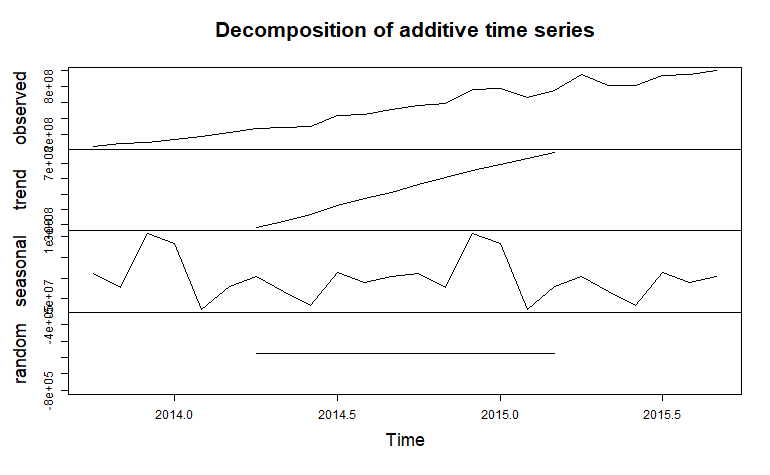

```r
plot(ts_sales_comp)
```

### 0.0.11 Model 8

```r
model_8 <- tslm(ts_sales ~ trend + season)

summary(model_8)
```

```
Call:
tslm(formula = ts_sales ~ trend + season)

Residuals:
      Min        1Q    Median        3Q       Max
-60480637 -23882207         0  23882207  60480637

Coefficients:
              Estimate Std. Error t value        Pr(>|t|)
(Intercept)   12041432   38027083   0.317          0.7574
trend         44734078    1648683  27.133 0.0000000000199 ***
season2      -84411678   48489226  -1.741          0.1096
season3      -56609479   48573239  -1.165          0.2685
season4       19564443   48712938   0.402          0.6957
season5      -89246187   48907846  -1.825          0.0953 .
season6     -127587529   49157307  -2.595          0.0249 *
season7      -41526169   49460495  -0.840          0.4190
season8      -71194695   49816429  -1.429          0.1807
season9      -60397180   50223987  -1.203          0.2544
season10      -8227987   48712938  -0.169          0.8689
season11     -27774674   48573239  -0.572          0.5789
season12      18438613   48489226   0.380          0.7110
---
Signif. codes:  0 ‘***’ 0.001 ‘**’ 0.01 ‘*’ 0.05 ‘.’ 0.1 ‘ ’ 1

Residual standard error: 48460000 on 11 degrees of freedom
Multiple R-squared:  0.9882,    Adjusted R-squared:  0.9754
F-statistic: 77.09 on 12 and 11 DF,  p-value: 0.000000007962
```

### 0.0.12 Model 9

```r
model_9 <- tslm(ts_sales ~ trend + season + ads_strategy1 + ads_strategy2 + ads_strategy3, data = df_train)

summary(model_9)
```

```
Call:
tslm(formula = ts_sales ~ trend + season + ads_strategy1 + ads_strategy2 +
    ads_strategy3, data = df_train)

Residuals:
      Min        1Q    Median        3Q       Max
-63211299 -18493769         0  18493769  63211299

Coefficients:
                Estimate Std. Error t value Pr(>|t|)
(Intercept)      4309067   45125337   0.095   0.9263
trend           42252974    5181509   8.155 0.000038 ***
season2        -95470943   57115212  -1.672   0.1332
season3        -75737256   67866781  -1.116   0.2968
season4        -13181049   84415646  -0.156   0.8798
season5       -110546041   78432103  -1.409   0.1964
season6       -140657789   66543341  -2.114   0.0675 .
season7        -47537067   63242034  -0.752   0.4738
season8        -76634207   60248541  -1.272   0.2391
season9        -86712773   69566589  -1.246   0.2479
season10        18872903   66618961   0.283   0.7841
season11         -811874   59354403  -0.014   0.9894
season12        39754411   60767124   0.654   0.5313
ads_strategy1  -21952246   93078951  -0.236   0.8195
ads_strategy2  118684781  179362540   0.662   0.5268
ads_strategy3  -66993225   79845156  -0.839   0.4258
---
Signif. codes:  0 ‘***’ 0.001 ‘**’ 0.01 ‘*’ 0.05 ‘.’ 0.1 ‘ ’ 1

Residual standard error: 53090000 on 8 degrees of freedom
Multiple R-squared:  0.9897,    Adjusted R-squared:  0.9705
F-statistic: 51.46 on 15 and 8 DF,  p-value: 0.00000278
```

```r
model_9 <- tslm(ts_sales ~ trend + season + ads_strategy1+ads_strategy2+ads_strategy3+salesVisit1+salesVisit2+salesVisit3+salesVisit4+salesVisit5,
                data = df_train)

summary(model_9)
```

```
Call:
tslm(formula = ts_sales ~ trend + season + ads_strategy1 + ads_strategy2 +
    ads_strategy3 + salesVisit1 + salesVisit2 + salesVisit3 +
    salesVisit4 + salesVisit5, data = df_train)

Residuals:
 [1] -10697611  33780747 -20284092 -12947834  -1719429  -3788573   1887229  15848854 -15824183
[10]   5224100   2544594   5976197  10697611 -33780747  20284092  12947834   1719429   3788573
[19]  -1887229 -15848854  15824183  -5224100  -2544594  -5976197

Coefficients:
                Estimate Std. Error t value Pr(>|t|)
(Intercept)   -142900185  175497494  -0.814   0.4751
trend           40396164    8282786   4.877   0.0165 *
season2       -135387010   87186077  -1.553   0.2183
season3       -355301387  186829301  -1.902   0.1534
season4       -319758780  254512693  -1.256   0.2979
season5       -223954129  157716754  -1.420   0.2507
season6       -259092555  167066460  -1.551   0.2187
season7       -331441496  209041996  -1.586   0.2110
season8       -324729563  224220298  -1.448   0.2434
season9       -271105842  194002897  -1.397   0.2567
season10       175741740  165423972   1.062   0.3660
season11       138205320  187634184   0.737   0.5148
season12       152792889  157247356   0.972   0.4029
ads_strategy1  -96902519  163388594  -0.593   0.5949
ads_strategy2  203746241  308436785   0.661   0.5561
ads_strategy3 -300675969  166715064  -1.804   0.1691
salesVisit1   -320093615  344361020  -0.930   0.4212
salesVisit2    485182181  493685347   0.983   0.3982
salesVisit3    128230194  231548522   0.554   0.6183
salesVisit4     75330326  199910640   0.377   0.7314
salesVisit5    -99828678   84481667  -1.182   0.3225
---
Signif. codes:  0 ‘***’ 0.001 ‘**’ 0.01 ‘*’ 0.05 ‘.’ 0.1 ‘ ’ 1

Residual standard error: 40220000 on 3 degrees of freedom
Multiple R-squared:  0.9978,    Adjusted R-squared:  0.9831
F-statistic: 67.79 on 20 and 3 DF,  p-value: 0.002529
```

```r
mctest::imcdiag(model_9, method = "VIF")
```

```
Error in `[.default`(model.matrix(mod), , -1) :
  incorrect number of dimensions
```

```r
car::vif(model_9)
```

```
                                 GVIF Df GVIF^(1/(2*Df))
trend         45909346055862592996248  0             Inf
season        45909346055862592996248  0             Inf
ads_strategy1 45909346055862592996248  0             Inf
ads_strategy2 45909346055862592996248  0             Inf
ads_strategy3 45909346055862592996248  0             Inf
salesVisit1   45909346055862592996248  0             Inf
salesVisit2   45909346055862592996248  0             Inf
salesVisit3   45909346055862592996248  0             Inf
salesVisit4   45909346055862592996248  0             Inf
salesVisit5   45909346055862592996248  0             Inf
```

```r
tslm(ts_sales ~ trend, data = df_train) %>%
  summary()
```

```
Call:
tslm(formula = ts_sales ~ trend, data = df_train)

Residuals:
      Min        1Q    Median        3Q       Max
-84927230 -25735795  -7193607  18052269 135208127

Coefficients:
             Estimate Std. Error t value            Pr(>|t|)
(Intercept) -10728068   23598315  -0.455               0.654
trend        43029155    1651538  26.054 <0.0000000000000002 ***
---
Signif. codes:  0 ‘***’ 0.001 ‘**’ 0.01 ‘*’ 0.05 ‘.’ 0.1 ‘ ’ 1

Residual standard error: 56010000 on 22 degrees of freedom
Multiple R-squared:  0.9686,    Adjusted R-squared:  0.9672
F-statistic: 678.8 on 1 and 22 DF,  p-value: < 0.00000000000000022
```

```r
tslm(ts_sales~., data = df_train) %>%
  summary()
```

```
Call:
tslm(formula = ts_sales ~ ., data = df_train)

Residuals:
ALL 24 residuals are 0: no residual degrees of freedom!

Coefficients: (7 not defined because of singularities)
                             Estimate Std. Error t value Pr(>|t|)
(Intercept)      63842149.99999845028        NaN     NaN      NaN
sales           935044602.00000500679        NaN     NaN      NaN
strategy1              -0.00000509853        NaN     NaN      NaN
strategy2               0.00000188571        NaN     NaN      NaN
strategy3               0.00000129444        NaN     NaN      NaN
salesVisit1            -0.00000057614        NaN     NaN      NaN
salesVisit2            -0.00001823491        NaN     NaN      NaN
salesVisit3             0.00000759159        NaN     NaN      NaN
salesVisit4             0.00000608637        NaN     NaN      NaN
salesVisit5            -0.00000111075        NaN     NaN      NaN
compBrand_4             0.00000091055        NaN     NaN      NaN
ads_strategy1           0.00000538270        NaN     NaN      NaN
ads_strategy2          -0.00000469614        NaN     NaN      NaN
ads_strategy3           0.00000078631        NaN     NaN      NaN
ads_salesVisit1        -0.00000252032        NaN     NaN      NaN
ads_salesVisit2         0.00001553212        NaN     NaN      NaN
ads_salesVisit3        -0.00000517516        NaN     NaN      NaN
ads_salesVisit4        -0.00000643904        NaN     NaN      NaN
ads_salesVisit5         0.00000196873        NaN     NaN      NaN
trend                   0.00000003492        NaN     NaN      NaN
season2                 0.00000106374        NaN     NaN      NaN
season3                 0.00000092206        NaN     NaN      NaN
season4                -0.00000090745        NaN     NaN      NaN
season5                -0.00000121482        NaN     NaN      NaN
season6                            NA         NA      NA       NA
season7                            NA         NA      NA       NA
season8                            NA         NA      NA       NA
season9                            NA         NA      NA       NA
season10                           NA         NA      NA       NA
season11                           NA         NA      NA       NA
season12                           NA         NA      NA       NA

Residual standard error: NaN on 0 degrees of freedom
Multiple R-squared:      1, Adjusted R-squared:    NaN
F-statistic:   NaN on 23 and 0 DF,  p-value: NA
```

### 0.0.13 Model 10

```r
library(forecast)
```

[output not shown]

[output cut: 14 more lines]

Using Range to convert negative values to positive

```r
preprocess_step <- caret::preProcess(df1_ads_only, method = c("center","scale"))

df_train <- predict(preprocess_step, newdata = df1_ads_only)


# To limit range between 0 to 1 & keep it positive
preprocess_step <- caret::preProcess(df_train, method = c("range"))

df_train <- predict(preprocess_step, newdata = df_train)

# to make it normally distributed
preprocess_step <- caret::preProcess(df_train, method = c("BoxCox"))

df_train <- predict(preprocess_step, newdata = df_train)


anyNA(df_train)
```

```
[1] FALSE
```

```r
ts_sales <- ts(df_train$sales, start = c(2013, 10), frequency = 12)
ts_sales
```

```
            Jan        Feb        Mar        Apr        May        Jun        Jul        Aug
2013
2014 0.08400182 0.12543300 0.17648131 0.23573382 0.23965360 0.25574293 0.39854148 0.42023701
2015 0.76203282 0.63573382 0.73983592 0.93919782 0.79822243 0.79580674 0.93277119 0.94329991
            Sep        Oct        Nov        Dec
2013            0.00000000 0.03618961 0.04680948
2014 0.48231541 0.54138560 0.55907020 0.74298086
2015 1.00000000
```

```r
ts_sales_comp <- decompose(ts_sales)
```

```r
ts_sales_comp
```

```
$x
            Jan        Feb        Mar        Apr        May        Jun        Jul        Aug
2013
2014 0.08400182 0.12543300 0.17648131 0.23573382 0.23965360 0.25574293 0.39854148 0.42023701
2015 0.76203282 0.63573382 0.73983592 0.93919782 0.79822243 0.79580674 0.93277119 0.94329991
            Sep        Oct        Nov        Dec
2013            0.00000000 0.03618961 0.04680948
2014 0.48231541 0.54138560 0.55907020 0.74298086
2015 1.00000000

$seasonal
              Jan          Feb          Mar          Apr          May          Jun          Jul
2013
2014  0.089107762 -0.081245092 -0.020507476  0.005362320 -0.035062324 -0.069766822  0.015773289
2015  0.089107762 -0.081245092 -0.020507476  0.005362320 -0.035062324 -0.069766822  0.015773289
              Aug          Sep          Oct          Nov          Dec
2013                            0.011583835 -0.023316271  0.114818036
2014 -0.012045007  0.005297749  0.011583835 -0.023316271  0.114818036
2015 -0.012045007  0.005297749

$trend
           Jan       Feb       Mar       Apr       May       Jun       Jul       Aug       Sep
2013
2014        NA        NA        NA 0.2309860 0.2753304 0.3261243 0.3833827 0.4328965 0.4776322
2015 0.6735396 0.7175934 0.7609579        NA        NA        NA        NA        NA        NA
           Oct       Nov       Dec
2013        NA        NA        NA
2014 0.5304163 0.5830010 0.6287773
2015

$random
              Jan          Feb          Mar          Apr          May          Jun          Jul
2013
2014           NA           NA           NA -0.000614523 -0.000614523 -0.000614523 -0.000614523
2015 -0.000614523 -0.000614523 -0.000614523           NA           NA           NA           NA
              Aug          Sep          Oct          Nov          Dec
2013                                     NA           NA           NA
2014 -0.000614523 -0.000614523 -0.000614523 -0.000614523 -0.000614523
2015           NA           NA

$figure
 [1]  0.011583835 -0.023316271  0.114818036  0.089107762 -0.081245092 -0.020507476  0.005362320
 [8] -0.035062324 -0.069766822  0.015773289 -0.012045007  0.005297749

$type
[1] "additive"

attr(,"class")
[1] "decomposed.ts"
```

[figure not shown]

```r
ts_sales_comp$trend
```

```
           Jan       Feb       Mar       Apr       May       Jun       Jul       Aug       Sep
2013
2014        NA        NA        NA 0.2309860 0.2753304 0.3261243 0.3833827 0.4328965 0.4776322
2015 0.6735396 0.7175934 0.7609579        NA        NA        NA        NA        NA        NA
           Oct       Nov       Dec
2013        NA        NA        NA
2014 0.5304163 0.5830010 0.6287773
2015
```

```r
Trend_comp <- data.frame(Trend=as.matrix(ts_sales_comp$trend), date= zoo::as.Date(time(ts_sales_comp$trend))) %>%
  pull(Trend)

Trend_comp
```

```
 [1]        NA        NA        NA        NA        NA        NA 0.2309860 0.2753304 0.3261243
[10] 0.3833827 0.4328965 0.4776322 0.5304163 0.5830010 0.6287773 0.6735396 0.7175934 0.7609579
[19]        NA        NA        NA        NA        NA        NA
```

```r
Seasonal_comp <- data.frame(Seasonal=as.matrix(ts_sales_comp$seasonal),
           date= zoo::as.Date(time(ts_sales_comp$trend))) %>%
  pull(Seasonal)

Seasonal_comp
```

```
 [1]  0.011583835 -0.023316271  0.114818036  0.089107762 -0.081245092 -0.020507476  0.005362320
 [8] -0.035062324 -0.069766822  0.015773289 -0.012045007  0.005297749  0.011583835 -0.023316271
[15]  0.114818036  0.089107762 -0.081245092 -0.020507476  0.005362320 -0.035062324 -0.069766822
[22]  0.015773289 -0.012045007  0.005297749
```

#### 0.0.13.1 Model

```r
model_10 <- tslm(ts_sales ~ Trend_comp + Seasonal_comp + ads_strategy1 + ads_strategy2 + ads_strategy3,
                 data = df_train)

summary(model_10)
```

```
Call:
tslm(formula = ts_sales ~ Trend_comp + Seasonal_comp + ads_strategy1 +
    ads_strategy2 + ads_strategy3, data = df_train)

Residuals:
       Min         1Q     Median         3Q        Max
-7.147e-17 -1.965e-17  3.413e-18  2.482e-17  6.179e-17

Coefficients:
                Estimate Std. Error    t value Pr(>|t|)
(Intercept)   -6.145e-04  1.091e-16 -5.635e+12   <2e-16 ***
Trend_comp     1.000e+00  1.413e-16  7.079e+15   <2e-16 ***
Seasonal_comp  1.000e+00  3.630e-16  2.755e+15   <2e-16 ***
ads_strategy1  1.401e-16  1.143e-16  1.226e+00    0.266
ads_strategy2  1.999e-17  1.404e-16  1.420e-01    0.891
ads_strategy3 -2.687e-18  5.383e-17 -5.000e-02    0.962
---
Signif. codes:  0 ‘***’ 0.001 ‘**’ 0.01 ‘*’ 0.05 ‘.’ 0.1 ‘ ’ 1

Residual standard error: 5.25e-17 on 6 degrees of freedom
  (12 observations deleted due to missingness)
Multiple R-squared:      1, Adjusted R-squared:      1
F-statistic: 3.07e+31 on 5 and 6 DF,  p-value: < 2.2e-16
```

```r
model_10_2 <- tslm(ts_sales ~ Trend_comp + Seasonal_comp,
                 data = df_train)

summary(model_10_2)
```

```
Call:
tslm(formula = ts_sales ~ Trend_comp + Seasonal_comp, data = df_train)

Residuals:
       Min         1Q     Median         3Q        Max
-6.168e-17 -2.834e-17 -1.649e-17  2.799e-17  9.284e-17

Coefficients:
                Estimate Std. Error    t value Pr(>|t|)
(Intercept)   -6.145e-04  4.712e-17 -1.304e+13   <2e-16 ***
Trend_comp     1.000e+00  8.921e-17  1.121e+16   <2e-16 ***
Seasonal_comp  1.000e+00  2.773e-16  3.607e+15   <2e-16 ***
---
Signif. codes:  0 ‘***’ 0.001 ‘**’ 0.01 ‘*’ 0.05 ‘.’ 0.1 ‘ ’ 1

Residual standard error: 5.098e-17 on 9 degrees of freedom
  (12 observations deleted due to missingness)
Multiple R-squared:      1, Adjusted R-squared:      1
F-statistic: 8.138e+31 on 2 and 9 DF,  p-value: < 2.2e-16
```